# Function-on-function regression under within-curve dependence: detailed results

## 10.7 Beat-to-beat errors (ECG strain)

The beat-to-beat difference curves are the one error source not shaped by any fit (design effect 21.7 against 19.9 for the REML residuals). With them, REML + CL2’s coverage changes by 0.1–1.2 pp (variance-matched) and 0.1–1.2 pp (own scale) relative to the REML-residual cells with the same truth, the bias-aware NCV interval’s by 0.3–1.1 pp and 0.7–1.5 pp, and the model-based intervals’ by -3.9 to -1.6 pp and -3.0 to -0.8 pp (Table 69). NCV’s β gain is larger with the variance-matched beat errors than with the REML residuals under every truth (ratios 0.73–0.91 vs 0.78–0.98) and smaller at the beats’ own scale (0.89–0.97).

Table 69: ECG strain, all 78 subjects: coverage per arm and NCV/REML MSE ratio by truth source and residual source, including the beat-to-beat difference curves.

| truth | residual | estimand | NCV + CL2 | NCV + CL2, bias-aware | REML + CL2 | REML, model-based | AR(1) working model | mse_ratio_ncv_reml |
| --- | --- | --- | --- | --- | --- | --- | --- | --- |
| REML |  | beta(s,t) | 0.899 | 0.929 | 0.943 | 0.559 |  | 0.951 |
| REML |  | beta(s,t) | 0.904 | 0.931 | 0.943 | 0.563 |  | 0.982 |
| REML |  | beta(s,t) | 0.932 | 0.944 | 0.945 | 0.536 |  | 0.970 |
| REML |  | beta(s,t) | 0.910 | 0.939 | 0.944 | 0.526 |  | 0.907 |
| MID |  | beta(s,t) | 0.900 | 0.931 | 0.943 | 0.558 |  | 0.890 |
| MID |  | beta(s,t) | 0.904 | 0.932 | 0.944 | 0.561 | 0.874 | 0.927 |
| MID |  | beta(s,t) | 0.933 | 0.946 | 0.945 | 0.534 |  | 0.943 |
| MID |  | beta(s,t) | 0.910 | 0.940 | 0.945 | 0.524 | 0.837 | 0.857 |
| NCV |  | beta(s,t) | 0.909 | 0.941 | 0.944 | 0.559 |  | 0.732 |
| NCV |  | beta(s,t) | 0.909 | 0.939 | 0.944 | 0.562 |  | 0.782 |
| NCV |  | beta(s,t) | 0.928 | 0.946 | 0.945 | 0.532 |  | 0.887 |
| NCV |  | beta(s,t) | 0.906 | 0.942 | 0.945 | 0.523 |  | 0.728 |
| REML |  | E(Y \| X) | 0.904 | 0.933 | 0.939 | 0.583 |  | 1.036 |
| REML |  | E(Y \| X) | 0.906 | 0.933 | 0.938 | 0.586 |  | 1.043 |
| REML |  | E(Y \| X) | 0.940 | 0.948 | 0.950 | 0.579 |  | 0.995 |
| REML |  | E(Y \| X) | 0.921 | 0.945 | 0.949 | 0.571 |  | 0.992 |
| MID |  | E(Y \| X) | 0.916 | 0.938 | 0.940 | 0.581 |  | 0.959 |
| MID |  | E(Y \| X) | 0.916 | 0.937 | 0.938 | 0.583 | 0.869 | 0.977 |
| MID |  | E(Y \| X) | 0.940 | 0.951 | 0.950 | 0.570 |  | 0.974 |
| MID |  | E(Y \| X) | 0.923 | 0.947 | 0.950 | 0.564 | 0.847 | 0.953 |
| NCV |  | E(Y \| X) | 0.918 | 0.942 | 0.940 | 0.582 |  | 0.875 |
| NCV |  | E(Y \| X) | 0.916 | 0.939 | 0.938 | 0.583 |  | 0.905 |
| NCV |  | E(Y \| X) | 0.935 | 0.950 | 0.950 | 0.569 |  | 0.962 |
| NCV |  | E(Y \| X) | 0.921 | 0.948 | 0.950 | 0.564 |  | 0.888 |

## 10.8 AR(1) in the plasmode study

In the common (MID truth, REML residuals) cell the AR(1) working model covers the mean at 0.67–0.93 and β at 0.44–0.91 across the nine datasets (Table 91), with ρ̂ at 0.45–0.99 (at its 0.99 cap on the running data) and median fit times of 28–162 s. It reaches 0.93 for both primary estimands on 0 datasets. The sensitivity cells (running under the REML- and NCV-fitted truths, ECG strain with beat errors) give 0.55–0.85.

## 10.9 Block arm on the dependent-curve datasets

The stress tests’ curve-flip cells generate independent errors across curves, so the only evidence about between-curve dependence is the contrast of block-flip against curve-flip cells. Under imposed block dependence REML + curve-clustered CL2 changes by -1.8 to 2.1 pp relative to the curve-flip cells (bias-aware NCV -2.1 to 0.9 pp). Leaving out and clustering on blocks does not help estimation: the paired MSE ratio block-NCV / NCV is 0.99–1.11 (Table 70), and under independent curves block clustering costs 0.1–2.9 pp of coverage. Verdicts: ocean mean: cost only; ocean beta: inconclusive; weather mean: hurts; weather beta: inconclusive; electricity mean: cost only; electricity beta: inconclusive. Block-clustered CL2 does not recover the shortfall on the weather data (REML + block CL2 0.89–0.90 against REML + curve CL2 0.90–0.91 under block flips); its 16 blocks are below the ≥ 40 clusters of the study’s operating range, and the mechanism is untested there. The partition-mismatch arm (150 km blocks against 250 km generating blocks) gives an MSE ratio of 1.00–1.04.

Table 70: Block arm on the three stress-test datasets: MSE ratio block-NCV / curve-NCV, and the coverage lost by block-clustered CL2 relative to curve-clustered CL2 within a fit and between the two recipes, under imposed block dependence (block flips) and under independent curves (curve flips).

| dataset | estimand | verdict | cells | mse_ratio_block | coverage_loss | coverage_loss_recipe | mse_ratio_mismatch |
| --- | --- | --- | --- | --- | --- | --- | --- |
| ocean | beta | inconclusive | block_flips | 1.105 [0.979, 1.278] | 0.006 [0.005, 0.007] | 0.006 [0.003, 0.009] |  |
| ocean | beta | inconclusive | curve_flips | 1.168 [1.029, 1.290] | 0.001 [-0.000, 0.002] | 0.004 [0.001, 0.007] |  |
| ocean | mean | cost only | block_flips | 0.995 [0.989, 1.001] | -0.006 [-0.007, -0.005] | -0.005 [-0.007, -0.004] |  |
| ocean | mean | cost only | curve_flips | 1.003 [0.997, 1.010] | 0.003 [0.001, 0.004] | 0.003 [0.002, 0.005] |  |
| weather | beta | inconclusive | block_flips | 1.017 [0.955, 1.090] | 0.011 [0.009, 0.014] | 0.014 [0.008, 0.019] | 1.039 [0.957, 1.128] |
| weather | beta | inconclusive | curve_flips | 1.061 [1.002, 1.132] | 0.010 [0.007, 0.014] | -0.007 [-0.014, -0.001] |  |
| weather | mean | hurts | block_flips | 1.014 [0.995, 1.032] | -0.006 [-0.010, -0.002] | -0.003 [-0.007, 0.002] | 0.999 [0.982, 1.015] |
| weather | mean | hurts | curve_flips | 1.009 [0.986, 1.030] | 0.029 [0.023, 0.033] | 0.026 [0.021, 0.031] |  |
| electricity | beta | inconclusive | block_flips | 1.021 [1.003, 1.045] | 0.000 [-0.000, 0.001] | -0.002 [-0.003, -0.000] |  |
| electricity | beta | inconclusive | curve_flips | 1.055 [0.977, 1.161] | 0.001 [-0.000, 0.001] | 0.000 [-0.001, 0.002] |  |
| electricity | mean | cost only | block_flips | 1.001 [0.995, 1.008] | -0.008 [-0.009, -0.006] | -0.008 [-0.009, -0.007] |  |
| electricity | mean | cost only | curve_flips | 1.004 [0.995, 1.013] | 0.001 [-0.000, 0.003] | 0.001 [-0.001, 0.002] |  |

## 10.10 The hybrid interval and coverage maps in the plasmode study

Table 71: Hybrid and bias-aware intervals next to REML + CL2 in the plasmode study by truth source (all subjects, model residuals, equal-weighted mean over the nine datasets): coverage (cov), 5% pointwise quantile (q05), and width and interval score (IS) relative to REML + CL2.

| truth | estimand | n_cells | cov REML+CL2 | cov bias-aware | cov hybrid | q05 REML+CL2 | q05 bias-aware | q05 hybrid | width bias-aware/REML+CL2 | width hybrid/REML+CL2 | IS bias-aware/REML+CL2 | IS hybrid/REML+CL2 |
| --- | --- | --- | --- | --- | --- | --- | --- | --- | --- | --- | --- | --- |
| REML | E(Y \| X) | 18 | 0.939 | 0.930 | 0.927 | 0.895 | 0.856 | 0.825 | 1.013 | 1 | 1.056 | 1.038 |
| MID | E(Y \| X) | 18 | 0.937 | 0.941 | 0.947 | 0.894 | 0.878 | 0.884 | 0.979 | 1 | 0.973 | 0.955 |
| NCV | E(Y \| X) | 18 | 0.935 | 0.946 | 0.954 | 0.887 | 0.880 | 0.897 | 0.972 | 1 | 0.936 | 0.918 |
| REML | beta(s,t) | 18 | 0.924 | 0.873 | 0.906 | 0.869 | 0.741 | 0.667 | 1.020 | 1 | 1.230 | 1.042 |
| MID | beta(s,t) | 18 | 0.932 | 0.918 | 0.962 | 0.886 | 0.801 | 0.877 | 0.909 | 1 | 0.926 | 0.861 |
| NCV | beta(s,t) | 18 | 0.925 | 0.938 | 0.970 | 0.881 | 0.860 | 0.918 | 0.906 | 1 | 0.830 | 0.823 |

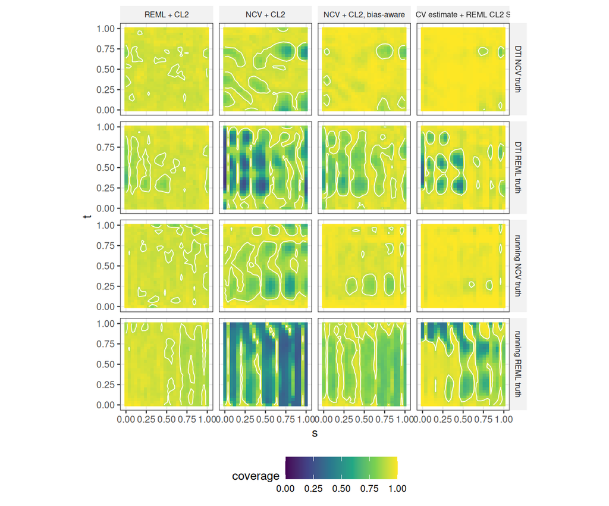

Figure 19: Pointwise coverage of β(s,t) on the running and the DTI data (all subjects, REML residuals) under the REML-fitted and the NCV-fitted truth, for REML + CL2, NCV + CL2, the bias-aware NCV interval and the hybrid; the white contour marks 0.90.

# 11 DTI application

The paper’s application (`analysis/dti-application-case.R` → `summaries/dti-case/`): right corticospinal tract FA on corpus-callosum FA and MS status, baseline visit, complete cases — the model of the DTI plasmode dataset — fitted with refund 79a346fb by REML and by curve-blocked NCV.

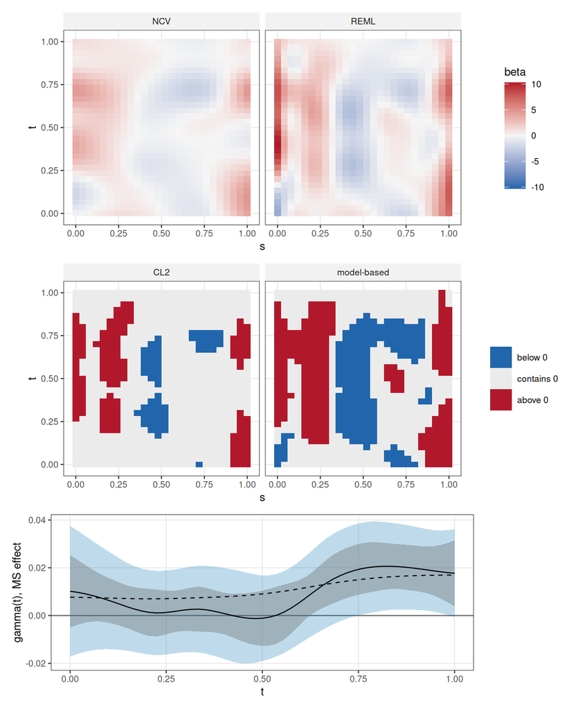

Figure 20: DTI application. Top: REML and NCV estimates of β(s,t). Middle: grid points where the pointwise 95% interval for β excludes zero (REML fit, model-based and CL2). Bottom: the MS effect γ(t) of the REML fit with model-based (grey) and CL2 (blue) pointwise intervals, and the NCV estimate (dashed).

Table 72: DTI application: median half-width and share of the grid where the pointwise 95% interval excludes zero (REML fit), and the median CL2/model-based SE ratio, for β(s,t) and γ(t).

| estimand | fit | se | median_halfwidth | share_excluding_zero | median_se_ratio_cl2_model |
| --- | --- | --- | --- | --- | --- |
| beta | REML | se_model | 0.914 | 0.526 | 2.28 |
| beta | REML | se_cl2 | 2.049 | 0.258 | 2.28 |
| gamma | REML | se_model | 0.010 | 0.382 | 1.88 |
| gamma | REML | se_cl2 | 0.018 | 0.236 | 1.88 |

Table 73: DTI fits: curves, grid points, total, surface and γ EDF, and the median absolute NCV − REML surface difference in units of REML’s CL2 SE.

| fit | G | D | total_edf | ff_edf | gamma_edf | r2 | median_abs_diff_in_se |
| --- | --- | --- | --- | --- | --- | --- | --- |
| REML | 92 | 55 | 69.5 | 53.8 | 4.93 | 0.726 |  |
| NCV | 92 | 55 | 48.9 | 35.1 | 1.96 | 0.717 | 0.641 |

# 12 The main recipes on every metric

One view of the four main interval constructions on every reported metric: grid-average coverage, the 5% quantile of pointwise coverage (q05), width and interval score relative to REML + CL2 (geometric means of per-cell ratios; the interval score is a proper scoring rule, < 1 is better), the median relative error of the centre, the median relative half-width and the median detection rate (definitions in the reading guide and Section 3.3.4). Synthetic: the core cells (three families, all signal levels), by dependence and G. Plasmode: the attached curve-flip cells with all subjects, all truth × residual sources. REML + CL2 and the model-based interval share the REML centre, NCV + CL2 and the bias-aware interval the NCV centre, so their relative errors coincide. AR(1) results on the same metrics are in Table 17 and Table 91, the comparators in Table 43 and Table 46, the NCV-centred corrections in Table 51.

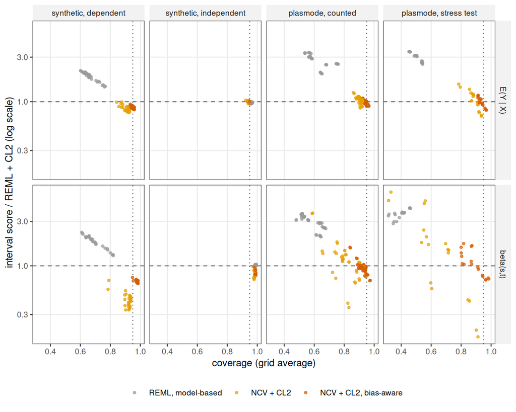

Figure 21: Interval score relative to REML + CL2 (log scale, < 1 better) against grid-average coverage, per cell, for β(s,t) and the test-cohort mean: synthetic core cells by dependence (both G) and plasmode cells (attached residuals, curve flips, all subjects; all truth × residual sources). Dotted: nominal coverage; dashed: equal interval score.

In the dependent synthetic cells at G = 100 the four constructions cover β at 0.712 (model-based), 0.945 (REML + CL2), 0.927 (NCV + CL2) and 0.981 (bias-aware), with interval scores 1.75, 1, 0.45 and 0.69 times REML + CL2’s; the NCV centre’s median relative error is 0.17 against 0.40 for REML, and the detection rates are 0.76 (REML + CL2), 0.96 (NCV + CL2) and 0.82 (bias-aware) (Table 74). In the dependent settings the model-based interval’s score is 1.75–1.85 times REML + CL2’s: the score’s penalty term prices its undercoverage. On the counted plasmode datasets the pooled β coverage is 0.578, 0.936, 0.821 and 0.925 and the interval scores 2.94, 1, 1.09 and 0.95 times REML + CL2’s (Table 75); per dataset the bias-aware interval’s score ratio is 0.80–1.14 and NCV + CL2’s 0.75–1.84 (Table 76). The interval score rewards the NCV centre’s smaller error even where the interval undercovers (NCV + CL2 in the dependent synthetic cells: coverage 0.927, score 0.45 times REML + CL2’s), so a better score is not evidence of calibration (Figure 21).

Table 74: Synthetic core cells, the main interval constructions on every metric, for the mean and β: cells, coverage (mean, minimum), q05, width and interval score relative to REML + CL2 (geometric mean; maximum per-cell score ratio), median relative error, median relative half-width and median detection rate. α(t) and γ(t) in metrics-synthetic.csv.

| errors | G | estimand | arm | cells | coverage | cov_min | q05 | width rel | IS rel | IS rel max | rel err | half-w | detect |
| --- | --- | --- | --- | --- | --- | --- | --- | --- | --- | --- | --- | --- | --- |
| dep. | 100 | E(Y \| X) | REML, model-based | 14 | 0.676 | 0.631 | 0.593 | 0.508 | 1.846 | 2.080 | 0.215 | 0.202 |  |
| dep. | 100 | E(Y \| X) | REML + CL2 | 14 | 0.943 | 0.940 | 0.913 | 1.000 | 1.000 | 1.000 | 0.215 | 0.431 |  |
| dep. | 100 | E(Y \| X) | NCV + CL2 | 14 | 0.918 | 0.876 | 0.845 | 0.769 | 0.859 | 0.993 | 0.178 | 0.334 |  |
| dep. | 100 | E(Y \| X) | NCV + CL2, bias-aware | 14 | 0.952 | 0.933 | 0.909 | 0.928 | 0.884 | 0.939 | 0.178 | 0.403 |  |
| dep. | 100 | beta(s,t) | REML, model-based | 14 | 0.712 | 0.653 | 0.626 | 0.544 | 1.755 | 2.106 | 0.404 | 0.442 | 0.896 |
| dep. | 100 | beta(s,t) | REML + CL2 | 14 | 0.945 | 0.940 | 0.919 | 1.000 | 1.000 | 1.000 | 0.404 | 0.823 | 0.756 |
| dep. | 100 | beta(s,t) | NCV + CL2 | 14 | 0.927 | 0.896 | 0.847 | 0.399 | 0.448 | 0.542 | 0.166 | 0.318 | 0.958 |
| dep. | 100 | beta(s,t) | NCV + CL2, bias-aware | 14 | 0.981 | 0.971 | 0.944 | 0.816 | 0.690 | 0.716 | 0.166 | 0.720 | 0.820 |
| dep. | 40 | E(Y \| X) | REML, model-based | 14 | 0.660 | 0.601 | 0.580 | 0.498 | 1.842 | 2.151 | 0.361 | 0.340 |  |
| dep. | 40 | E(Y \| X) | REML + CL2 | 14 | 0.930 | 0.921 | 0.898 | 1.000 | 1.000 | 1.000 | 0.361 | 0.740 |  |
| dep. | 40 | E(Y \| X) | NCV + CL2 | 14 | 0.896 | 0.842 | 0.813 | 0.706 | 0.833 | 0.989 | 0.272 | 0.527 |  |
| dep. | 40 | E(Y \| X) | NCV + CL2, bias-aware | 14 | 0.948 | 0.930 | 0.904 | 0.933 | 0.856 | 0.922 | 0.272 | 0.687 |  |
| dep. | 40 | beta(s,t) | REML, model-based | 14 | 0.686 | 0.609 | 0.607 | 0.535 | 1.833 | 2.288 | 0.731 | 0.760 | 0.748 |
| dep. | 40 | beta(s,t) | REML + CL2 | 14 | 0.929 | 0.923 | 0.899 | 1.000 | 1.000 | 1.000 | 0.731 | 1.420 | 0.497 |
| dep. | 40 | beta(s,t) | NCV + CL2 | 14 | 0.898 | 0.785 | 0.817 | 0.337 | 0.409 | 0.698 | 0.242 | 0.462 | 0.895 |
| dep. | 40 | beta(s,t) | NCV + CL2, bias-aware | 14 | 0.976 | 0.948 | 0.942 | 0.847 | 0.671 | 0.753 | 0.242 | 1.270 | 0.593 |
| iid | 100 | E(Y \| X) | REML, model-based | 7 | 0.965 | 0.962 | 0.934 | 1.020 | 0.987 | 0.992 | 0.091 | 0.191 |  |
| iid | 100 | E(Y \| X) | REML + CL2 | 7 | 0.958 | 0.949 | 0.921 | 1.000 | 1.000 | 1.000 | 0.091 | 0.191 |  |
| iid | 100 | E(Y \| X) | NCV + CL2 | 7 | 0.946 | 0.939 | 0.889 | 0.930 | 0.977 | 1.034 | 0.088 | 0.174 |  |
| iid | 100 | E(Y \| X) | NCV + CL2, bias-aware | 7 | 0.954 | 0.945 | 0.905 | 0.965 | 0.978 | 1.022 | 0.088 | 0.182 |  |
| iid | 100 | beta(s,t) | REML, model-based | 7 | 0.989 | 0.983 | 0.971 | 1.024 | 1.013 | 1.038 | 0.123 | 0.327 | 0.972 |
| iid | 100 | beta(s,t) | REML + CL2 | 7 | 0.985 | 0.979 | 0.964 | 1.000 | 1.000 | 1.000 | 0.123 | 0.321 | 0.973 |
| iid | 100 | beta(s,t) | NCV + CL2 | 7 | 0.981 | 0.976 | 0.936 | 0.775 | 0.794 | 0.922 | 0.095 | 0.229 | 0.984 |
| iid | 100 | beta(s,t) | NCV + CL2, bias-aware | 7 | 0.988 | 0.986 | 0.951 | 0.845 | 0.841 | 0.934 | 0.095 | 0.255 | 0.979 |
| iid | 40 | E(Y \| X) | REML, model-based | 7 | 0.964 | 0.952 | 0.927 | 1.027 | 0.969 | 0.975 | 0.135 | 0.295 |  |
| iid | 40 | E(Y \| X) | REML + CL2 | 7 | 0.951 | 0.925 | 0.906 | 1.000 | 1.000 | 1.000 | 0.135 | 0.295 |  |
| iid | 40 | E(Y \| X) | NCV + CL2 | 7 | 0.941 | 0.923 | 0.884 | 0.947 | 0.990 | 1.034 | 0.133 | 0.273 |  |
| iid | 40 | E(Y \| X) | NCV + CL2, bias-aware | 7 | 0.949 | 0.935 | 0.898 | 0.980 | 0.984 | 1.007 | 0.133 | 0.280 |  |
| iid | 40 | beta(s,t) | REML, model-based | 7 | 0.990 | 0.984 | 0.969 | 1.032 | 1.014 | 1.032 | 0.164 | 0.455 | 0.944 |
| iid | 40 | beta(s,t) | REML + CL2 | 7 | 0.985 | 0.973 | 0.957 | 1.000 | 1.000 | 1.000 | 0.164 | 0.449 | 0.945 |
| iid | 40 | beta(s,t) | NCV + CL2 | 7 | 0.981 | 0.973 | 0.942 | 0.817 | 0.834 | 0.981 | 0.135 | 0.338 | 0.960 |
| iid | 40 | beta(s,t) | NCV + CL2, bias-aware | 7 | 0.987 | 0.979 | 0.954 | 0.874 | 0.865 | 0.986 | 0.135 | 0.362 | 0.955 |

Table 75: Plasmode (attached residuals, curve flips, all subjects; all truth × residual sources), the main interval constructions on every metric by dataset role and estimand; columns as in the synthetic table.

| role | estimand | arm | cells | coverage | cov_min | q05 | width rel | IS rel | IS rel max | rel err | half-w | detect |
| --- | --- | --- | --- | --- | --- | --- | --- | --- | --- | --- | --- | --- |
| counted | E(Y \| X) | REML, model-based | 42 | 0.620 | 0.538 | 0.310 | 0.427 | 2.768 | 3.36 | 0.136 | 0.091 |  |
| counted | E(Y \| X) | REML + CL2 | 42 | 0.942 | 0.930 | 0.895 | 1.000 | 1.000 | 1.00 | 0.136 | 0.270 |  |
| counted | E(Y \| X) | NCV + CL2 | 42 | 0.909 | 0.861 | 0.789 | 0.866 | 1.033 | 1.25 | 0.134 | 0.242 |  |
| counted | E(Y \| X) | NCV + CL2, bias-aware | 42 | 0.942 | 0.925 | 0.877 | 0.981 | 0.991 | 1.09 | 0.134 | 0.264 |  |
| counted | beta(s,t) | REML, model-based | 42 | 0.578 | 0.479 | 0.294 | 0.395 | 2.941 | 3.64 | 0.836 | 0.604 | 0.825 |
| counted | beta(s,t) | REML + CL2 | 42 | 0.936 | 0.915 | 0.886 | 1.000 | 1.000 | 1.00 | 0.836 | 1.752 | 0.507 |
| counted | beta(s,t) | NCV + CL2 | 42 | 0.821 | 0.586 | 0.590 | 0.568 | 1.087 | 3.68 | 0.684 | 0.886 | 0.626 |
| counted | beta(s,t) | NCV + CL2, bias-aware | 42 | 0.925 | 0.838 | 0.820 | 0.924 | 0.951 | 1.58 | 0.684 | 1.495 | 0.441 |
| counted | alpha(t) | REML, model-based | 42 | 0.593 | 0.412 | 0.323 | 0.392 | 2.899 | 4.39 | 0.411 | 0.226 |  |
| counted | alpha(t) | REML + CL2 | 42 | 0.943 | 0.928 | 0.912 | 1.000 | 1.000 | 1.00 | 0.411 | 0.922 |  |
| counted | alpha(t) | NCV + CL2 | 42 | 0.914 | 0.858 | 0.839 | 0.899 | 1.091 | 1.49 | 0.385 | 0.874 |  |
| counted | alpha(t) | NCV + CL2, bias-aware | 42 | 0.938 | 0.919 | 0.881 | 0.984 | 1.050 | 1.25 | 0.385 | 0.892 |  |
| counted | gamma(t) | REML, model-based | 42 | 0.628 | 0.517 | 0.375 | 0.441 | 2.639 | 3.52 | 0.602 | 0.483 | 0.729 |
| counted | gamma(t) | REML + CL2 | 42 | 0.944 | 0.928 | 0.906 | 1.000 | 1.000 | 1.00 | 0.602 | 1.427 | 0.379 |
| counted | gamma(t) | NCV + CL2 | 42 | 0.901 | 0.810 | 0.812 | 0.873 | 1.065 | 1.70 | 0.577 | 1.139 | 0.477 |
| counted | gamma(t) | NCV + CL2, bias-aware | 42 | 0.934 | 0.900 | 0.868 | 0.978 | 1.024 | 1.23 | 0.577 | 1.387 | 0.380 |
| stress test | E(Y \| X) | REML, model-based | 18 | 0.498 | 0.452 | 0.291 | 0.343 | 3.031 | 3.45 | 0.230 | 0.153 |  |
| stress test | E(Y \| X) | REML + CL2 | 18 | 0.929 | 0.912 | 0.884 | 1.000 | 1.000 | 1.00 | 0.230 | 0.450 |  |
| stress test | E(Y \| X) | NCV + CL2 | 18 | 0.884 | 0.784 | 0.766 | 0.808 | 1.035 | 1.54 | 0.192 | 0.321 |  |
| stress test | E(Y \| X) | NCV + CL2, bias-aware | 18 | 0.935 | 0.912 | 0.866 | 1.004 | 0.985 | 1.17 | 0.192 | 0.447 |  |
| stress test | beta(s,t) | REML, model-based | 18 | 0.395 | 0.315 | 0.241 | 0.274 | 3.597 | 4.18 | 1.063 | 0.561 | 0.766 |
| stress test | beta(s,t) | REML + CL2 | 18 | 0.911 | 0.840 | 0.867 | 1.000 | 1.000 | 1.00 | 1.063 | 2.248 | 0.321 |
| stress test | beta(s,t) | NCV + CL2 | 18 | 0.642 | 0.316 | 0.365 | 0.300 | 1.314 | 6.18 | 0.678 | 0.627 | 0.528 |
| stress test | beta(s,t) | NCV + CL2, bias-aware | 18 | 0.885 | 0.800 | 0.781 | 0.990 | 1.048 | 1.73 | 0.678 | 2.109 | 0.141 |
| stress test | alpha(t) | REML, model-based | 18 | 0.444 | 0.397 | 0.314 | 0.308 | 3.301 | 3.74 | 0.443 | 0.264 |  |
| stress test | alpha(t) | REML + CL2 | 18 | 0.924 | 0.884 | 0.874 | 1.000 | 1.000 | 1.00 | 0.443 | 1.070 |  |
| stress test | alpha(t) | NCV + CL2 | 18 | 0.885 | 0.724 | 0.825 | 0.807 | 0.969 | 1.31 | 0.461 | 0.974 |  |
| stress test | alpha(t) | NCV + CL2, bias-aware | 18 | 0.933 | 0.876 | 0.894 | 0.978 | 0.960 | 1.13 | 0.461 | 1.038 |  |
| stress test | gamma(t) | REML, model-based | 18 | 0.409 | 0.357 | 0.296 | 0.280 | 3.287 | 3.92 | 0.222 | 0.172 | 0.974 |
| stress test | gamma(t) | REML + CL2 | 18 | 0.934 | 0.882 | 0.914 | 1.000 | 1.000 | 1.00 | 0.222 | 0.597 | 0.809 |
| stress test | gamma(t) | NCV + CL2 | 18 | 0.814 | 0.329 | 0.712 | 0.733 | 1.231 | 2.86 | 0.225 | 0.468 | 0.964 |
| stress test | gamma(t) | NCV + CL2, bias-aware | 18 | 0.914 | 0.745 | 0.861 | 0.986 | 1.057 | 1.52 | 0.225 | 0.504 | 0.724 |

Table 76: Plasmode, β(s,t), per dataset: coverage, q05, width and interval score relative to REML + CL2, median relative error, relative half-width and detection rate, over the dataset’s truth × residual cells (all subjects, curve flips).

| dataset | arm | cells | coverage | q05 | width rel | IS rel | rel err | half-w | detect |
| --- | --- | --- | --- | --- | --- | --- | --- | --- | --- |
| ECG strain | REML, model-based | 12 | 0.545 | 0.219 | 0.351 | 3.241 | 0.698 | 0.466 | 0.836 |
| ECG strain | REML + CL2 | 12 | 0.944 | 0.901 | 1.000 | 1.000 | 0.698 | 1.417 | 0.442 |
| ECG strain | NCV + CL2 | 12 | 0.912 | 0.809 | 0.844 | 1.009 | 0.676 | 1.177 | 0.461 |
| ECG strain | NCV + CL2, bias-aware | 12 | 0.938 | 0.862 | 0.930 | 0.974 | 0.676 | 1.300 | 0.404 |
| AF trial | REML, model-based | 6 | 0.666 | 0.363 | 0.498 | 2.565 | 0.865 | 0.945 | 0.689 |
| AF trial | REML + CL2 | 6 | 0.938 | 0.879 | 1.000 | 1.000 | 0.865 | 1.824 | 0.372 |
| AF trial | NCV + CL2 | 6 | 0.789 | 0.485 | 0.493 | 1.190 | 0.714 | 0.963 | 0.533 |
| AF trial | NCV + CL2, bias-aware | 6 | 0.916 | 0.772 | 0.922 | 0.944 | 0.714 | 1.534 | 0.303 |
| running | REML, model-based | 6 | 0.507 | 0.268 | 0.344 | 3.240 | 0.825 | 0.600 | 0.865 |
| running | REML + CL2 | 6 | 0.919 | 0.873 | 1.000 | 1.000 | 0.825 | 1.851 | 0.637 |
| running | NCV + CL2 | 6 | 0.734 | 0.441 | 0.527 | 1.497 | 0.661 | 0.678 | 0.735 |
| running | NCV + CL2, bias-aware | 6 | 0.892 | 0.766 | 0.979 | 1.099 | 0.661 | 1.516 | 0.578 |
| DTI | REML, model-based | 6 | 0.632 | 0.475 | 0.491 | 2.103 | 0.633 | 0.596 | 0.872 |
| DTI | REML + CL2 | 6 | 0.927 | 0.876 | 1.000 | 1.000 | 0.633 | 1.169 | 0.638 |
| DTI | NCV + CL2 | 6 | 0.846 | 0.586 | 0.647 | 1.034 | 0.469 | 0.760 | 0.772 |
| DTI | NCV + CL2, bias-aware | 6 | 0.926 | 0.806 | 0.947 | 0.945 | 0.469 | 1.083 | 0.562 |
| gait | REML, model-based | 6 | 0.517 | 0.231 | 0.308 | 3.596 | 1.007 | 0.653 | 0.825 |
| gait | REML + CL2 | 6 | 0.939 | 0.903 | 1.000 | 1.000 | 1.007 | 2.388 | 0.546 |
| gait | NCV + CL2 | 6 | 0.816 | 0.547 | 0.562 | 1.283 | 0.765 | 1.024 | 0.650 |
| gait | NCV + CL2, bias-aware | 6 | 0.925 | 0.833 | 0.895 | 0.949 | 0.765 | 1.931 | 0.486 |
| ECG 8-lead | REML, model-based | 6 | 0.638 | 0.282 | 0.468 | 2.880 | 2.427 | 2.197 | 0.567 |
| ECG 8-lead | REML + CL2 | 6 | 0.942 | 0.873 | 1.000 | 1.000 | 2.427 | 4.878 | 0.216 |
| ECG 8-lead | NCV + CL2 | 6 | 0.739 | 0.449 | 0.284 | 0.747 | 0.806 | 0.851 | 0.568 |
| ECG 8-lead | NCV + CL2, bias-aware | 6 | 0.937 | 0.840 | 0.868 | 0.797 | 0.806 | 4.371 | 0.210 |
| ocean | REML, model-based | 6 | 0.412 | 0.224 | 0.266 | 3.707 | 1.035 | 0.542 | 0.791 |
| ocean | REML + CL2 | 6 | 0.925 | 0.887 | 1.000 | 1.000 | 1.035 | 2.248 | 0.450 |
| ocean | NCV + CL2 | 6 | 0.708 | 0.281 | 0.340 | 1.430 | 0.667 | 0.527 | 0.528 |
| ocean | NCV + CL2, bias-aware | 6 | 0.916 | 0.794 | 1.003 | 1.028 | 0.667 | 2.109 | 0.178 |
| weather | REML, model-based | 6 | 0.341 | 0.233 | 0.279 | 3.321 | 1.007 | 0.561 | 0.766 |
| weather | REML + CL2 | 6 | 0.882 | 0.833 | 1.000 | 1.000 | 1.007 | 1.979 | 0.321 |
| weather | NCV + CL2 | 6 | 0.608 | 0.415 | 0.414 | 1.838 | 0.678 | 0.771 | 0.538 |
| weather | NCV + CL2, bias-aware | 6 | 0.828 | 0.715 | 0.936 | 1.142 | 0.678 | 1.786 | 0.228 |
| electricity | REML, model-based | 6 | 0.432 | 0.266 | 0.276 | 3.781 | 3.418 | 2.224 | 0.478 |
| electricity | REML + CL2 | 6 | 0.927 | 0.881 | 1.000 | 1.000 | 3.418 | 5.722 | 0.076 |
| electricity | NCV + CL2 | 6 | 0.611 | 0.398 | 0.192 | 0.863 | 0.815 | 0.564 | 0.512 |
| electricity | NCV + CL2, bias-aware | 6 | 0.911 | 0.835 | 1.035 | 0.981 | 0.815 | 5.623 | 0.094 |

# 13 Cross-study assessment

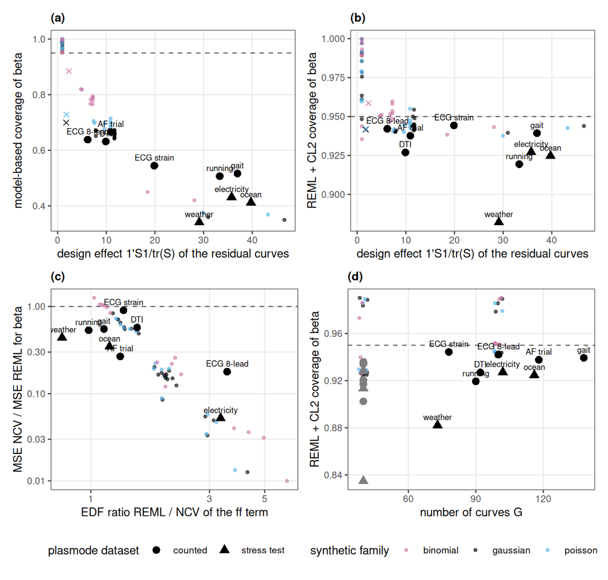

Figure 22: Synthetic cells (small coloured points, G = 100; colour = family) and plasmode datasets (large black symbols: circles = counted, triangles = stress tests; labelled) on common axes. (a) model-based coverage of β against the design effect of the residual curves (synthetic: realized values from 20 replicates per cell without uncertainty, design values for the two negative-binomial-as-Poisson cells; the D = 241 dense-grid cells are included; crosses mark the sign-changing and misregistration cells, whose dependence the design effect does not capture); (b) REML + CL2 coverage of β against the same; axes cover all points; (c) NCV/REML MSE ratio for β against the REML/NCV EDF ratio of the ff term (plasmode: MID truth, EDF ratio of the two real-data fits; synthetic: all cells with a smooth truth at G = 100); (d) REML + CL2 coverage of β against G (synthetic: core cells at both G; plasmode: the G = all pool means, and in grey the same datasets at G = 40).

Table 77 summarises, property by property, what the synthetic study found and what the nine plasmode datasets can say about it; the evidence behind each row is in the list that follows. Associations across datasets are Spearman rank correlations over n = 9 (or the 6 counted) datasets with two-sided permutation p-values; at n = 9 a |rho| below about 0.6 is uninformative, and the datasets’ properties are confounded with each other and with the data source. Each correlation uses, per dataset, the pool mean over its attached curve-flip cells at G = all subjects (all truth × residual combinations) for coverages, the geometric mean over residual sources of the MID-truth cell ratios for the NCV gain, the (MID truth, REML residual) cell for AR(1), and the diagnostics of the REML residual curves (`cross-study-dataset-outcomes.csv`). The synthetic study spans design effects 5–12 in its dependent core cells (D = 61; realized values; realized values are means over 20 replicates without an uncertainty estimate and are missing for 2 cells, the negative-binomial data fitted as Poisson, where the design values stand in); the plasmode datasets span 6–40 with grid sizes 30–101. Because 1’Σ1/trΣ grows with the grid size, the normalisation DE/D = (1’Σ1/trΣ)/D (0.06–0.75) is reported beside it. The design effect is the grid-mean variance inflation and does not capture sign-changing or misregistration dependence: the sign-changing cells have realized DE 1.7–2.3 and the misregistration cells 1.5–1.9 while their model-based coverage is 0.70–0.88.

Table 77: Cross-study assessment: for each data or model property varied in the synthetic study, its synthetic effect on inference and on estimation, what the plasmode data can say about it, and a verdict. Associations are Spearman rho with permutation p over the nine datasets unless marked counted only.

[output not shown]

Evidence per row:

- *Dependence strength.* Model-based shortfall for β against DE: rho = 0.73, p = 0.03, n = 9; against DE/D: rho = 0.77, p = 0.02, n = 9. The dataset with the smallest DE, ECG 8-lead (DE 6.2, DE/D 0.06), still has a shortfall of 31.2 pp; the dataset furthest above the shortfall-on-log-DE trend is weather. REML + CL2 β coverage against DE: rho = -0.33, p = 0.37, n = 9 (counted only rho = -0.14, p = 0.79, n = 6).
- *Dependence shape.* ECG 8-lead’s residuals have the strongest sign-changing correlations of all datasets (minimum r -0.68) and the most extreme variance profile (SD ratio 42). The design effect 1’Σ1/trΣ is a grid-mean variance inflation that does not capture such features (see the sign-changing and misregistration cells above); REML + CL2 β coverage against the SD ratio is 0.80 (p = 0.01) over all nine datasets and 0.66 (p = 0.18) over the counted six, i.e. driven by the stress tests.
- *Misregistration.* The two cardiac datasets with real misregistration (ECG strain 63%, AF 43%) have REML + CL2 β coverage 0.944 and 0.938 and AR(1) coverage 0.874 and 0.838; AR(1)’s lowest real-data coverages are on weather and electricity (phase shares 6% and 0%).
- *Number of curves.* Paired within-dataset losses at G = 40 are in Table 87 and the synthetic ones in Table 80.
- *Covariate rank.* MID-truth β gain against rank: rho = 0.19, p = 0.63, n = 9; REML + CL2 β coverage against rank: rho = 0.67, p = 0.05, n = 9 (counted only rho = 0.38, p = 0.48, n = 6). Counted datasets ordered by REML + CL2 β coverage: running 0.919, DTI 0.927, AF trial 0.938, gait 0.939, ECG 8-lead 0.942, ECG strain 0.944.
- *Truth roughness / EDF gap.* MID-truth β gain against the EDF ratio: -0.33 (p = 0.39, n = 9). Datasets ordered by the MID-truth ratio (largest gain last): ECG strain 0.90 (EDF ratio 1.35); DTI 0.57 (EDF ratio 1.53); gait 0.55 (EDF ratio 1.13); running 0.53 (EDF ratio 0.98); weather 0.44 (EDF ratio 0.77); ocean 0.35 (EDF ratio 1.19); AF trial 0.27 (EDF ratio 1.31); ECG 8-lead 0.18 (EDF ratio 3.53); electricity 0.05 (EDF ratio 3.33). In Figure 22 (c) 5 of 9 datasets lie below the synthetic cells’ log-log trend.
- *Signal.* Shortfall against R²: rho = 0.55, p = 0.12, n = 9; MID gain against R²: rho = 0.50, p = 0.17, n = 9.
- *Term type.* Datasets with resolved α(t) or γ(t) gains under the NCV truth are listed in Section 10.4; the surface gain is the only one present on every dataset under the NCV and MID truths (9 of 9).
- *Basis size.* MID-truth β gains ordered: electricity 0.05, ECG 8-lead 0.18, AF trial 0.27, ocean 0.35, weather 0.44, running 0.53, gait 0.55, DTI 0.57, ECG strain 0.90; among the counted datasets ECG 8-lead ranks 1 of 6 (1 = largest gain).
- *Other remedies.* Per-cell results and CL2 on the GLS and pcre fits: Section 7, Section 7.1.
- *NCV-centred corrections.* Per-dataset results: Section 8, Section 9; all metrics of the main recipes side by side: Section 12.
- *Between-curve dependence.* Block-flip minus curve-flip coverages per recipe and dataset: ocean E(Y | X) bias-aware NCV (curve) -0.5 pp; ocean E(Y | X) REML + curve CL2 -0.3 pp; ocean beta(s,t) bias-aware NCV (curve) 0.9 pp; ocean beta(s,t) REML + curve CL2 1.0 pp; weather E(Y | X) bias-aware NCV (curve) -2.1 pp; weather E(Y | X) REML + curve CL2 -1.8 pp; weather beta(s,t) bias-aware NCV (curve) -0.6 pp; weather beta(s,t) REML + curve CL2 2.1 pp; electricity E(Y | X) bias-aware NCV (curve) -0.9 pp; electricity E(Y | X) REML + curve CL2 0.3 pp; electricity beta(s,t) bias-aware NCV (curve) -1.7 pp; electricity beta(s,t) REML + curve CL2 -0.7 pp.

# 14 Computing time

All times are elapsed seconds on one core with single-threaded BLAS (OpenBLAS, `OPENBLAS_NUM_THREADS=1`). The study runs used LRZ CoolMUC-4: the serial cluster (`serial_std`, one core per task) for the synthetic and plasmode studies, the comparators and the REML smoothing-parameter runs, and partly its `cm4` nodes, which are slower per core, for the NCV smoothing-parameter runs. The recipe benchmark (`analysis/timing-benchmark.R`) fits REML, NCV and AR(1) to the same data sets, Gaussian, G = 100, D = 61, 10 replicates for each of the nine error processes of the AR(1) cells; its machine is not recorded (per core, the LRZ serial nodes and the development laptop, an Intel Core i7-8665U, run at about the same speed). “Per fit” and “per replicate” rows summarise individual fits; “cell median” rows summarise the per-cell median times stored with the study summaries, so their spread is across cells (families, G, D and datasets differ). The REML fit time excludes CL2; the CL2 rows are the covariance computation alone. No times were recorded for the one- and two-step bias corrections of the NCV fit (`ncv-rbc/`); each step is a linear map of the fit’s own matrices (Section 8). The hybrid and the bias-aware interval need both fits and their CL2 covariances, nothing else.

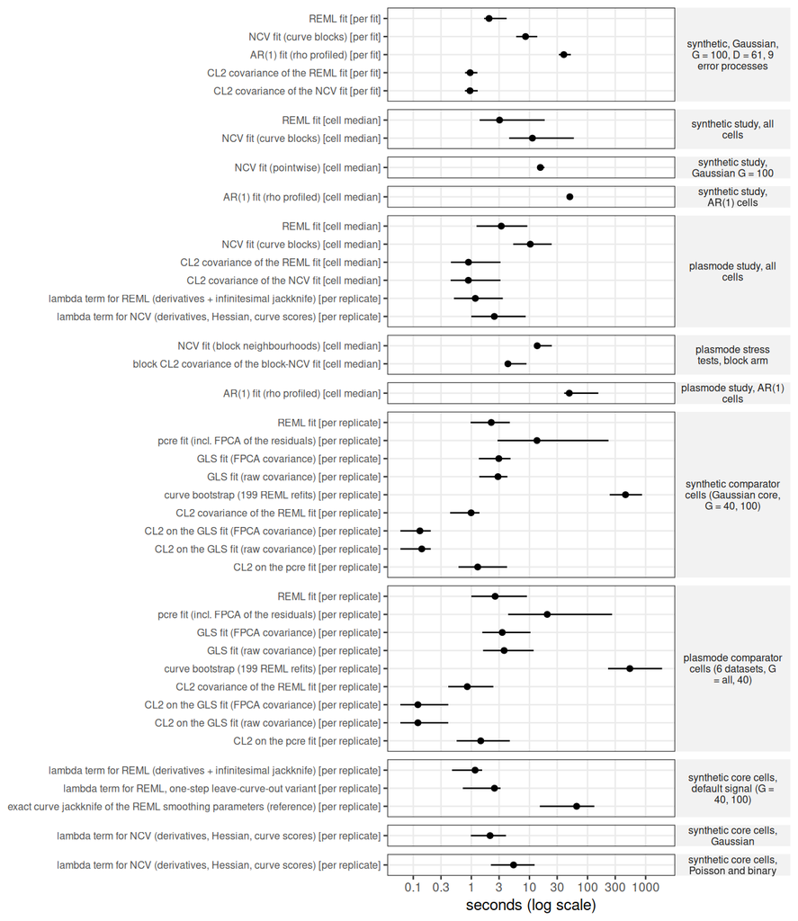

Figure 23: Computing time per component (median, bar from the 10% to the 90% quantile; log scale), by setting. Cell-median rows spread over cells, per-fit and per-replicate rows over fits.

On identical data (Gaussian, G = 100) the median REML fit takes 2.0 s, the curve-blocked NCV fit 8.6 s and the AR(1) fit with ρ profiled 39 s (12 grid fits plus a refinement); a CL2 covariance adds 1.0 s. REML + CL2 therefore costs about 3 s per data set, NCV + CL2 about 10 s and the bias-aware interval (both fits, both covariances) about 12 s. Among the comparators the pcre fit has a median of 20 s on the plasmode cells with a long tail (90% quantile 265 s), the GLS fits take 2.9–3.7 s against 2.2–2.6 s for the REML fit in the same cells, and the curve bootstrap with 199 refits takes a median of 535 s per data set; CL2 on a GLS or pcre fit adds a median of 0.12–1.45 s. The curve-robust smoothing-parameter term adds a median of 1.2 s to a REML fit and 2.1–2.5 s to a Gaussian NCV fit; the exact curve jackknife it approximates takes 65 s (Table 78, Figure 23).

Table 78: Computing time (seconds, one core): median and 10%–90% quantiles per component and setting; n = fits, replicates or cells.

| component | setting | unit | hardware | n | median | q10 | q90 |
| --- | --- | --- | --- | --- | --- | --- | --- |
| REML fit | synthetic, Gaussian, G = 100, D = 61, 9 error processes | per fit | 1 core | 90 | 2.02 | 1.66 | 4.04 |
| NCV fit (curve blocks) | synthetic, Gaussian, G = 100, D = 61, 9 error processes | per fit | 1 core | 90 | 8.56 | 5.92 | 13.62 |
| AR(1) fit (ρ profiled) | synthetic, Gaussian, G = 100, D = 61, 9 error processes | per fit | 1 core | 90 | 39.05 | 32.06 | 51.54 |
| CL2 covariance of the REML fit | synthetic, Gaussian, G = 100, D = 61, 9 error processes | per fit | 1 core | 90 | 0.95 | 0.78 | 1.27 |
| CL2 covariance of the NCV fit | synthetic, Gaussian, G = 100, D = 61, 9 error processes | per fit | 1 core | 90 | 0.95 | 0.78 | 1.29 |
| REML fit | synthetic study, all cells | cell median | LRZ serial node, 1 core | 123 | 3.06 | 1.39 | 18.30 |
| NCV fit (curve blocks) | synthetic study, all cells | cell median | LRZ serial node, 1 core | 123 | 11.24 | 4.48 | 58.04 |
| NCV fit (pointwise) | synthetic study, Gaussian G = 100 | cell median | LRZ serial node, 1 core | 3 | 15.39 | 13.81 | 18.12 |
| AR(1) fit (ρ profiled) | synthetic study, AR(1) cells | cell median | LRZ serial node, 1 core | 9 | 49.49 | 45.80 | 51.83 |
| REML fit | plasmode study, all cells | cell median | LRZ serial node, 1 core | 130 | 3.27 | 1.23 | 9.18 |
| NCV fit (curve blocks) | plasmode study, all cells | cell median | LRZ serial node, 1 core | 130 | 10.34 | 5.25 | 24.09 |
| NCV fit (block neighbourhoods) | plasmode stress tests, block arm | cell median | LRZ serial node, 1 core | 26 | 13.60 | 12.28 | 24.29 |
| AR(1) fit (ρ profiled) | plasmode study, AR(1) cells | cell median | LRZ serial node, 1 core | 12 | 48.49 | 39.63 | 153.30 |
| CL2 covariance of the REML fit | plasmode study, all cells | cell median | LRZ serial node, 1 core | 130 | 0.89 | 0.44 | 3.17 |
| CL2 covariance of the NCV fit | plasmode study, all cells | cell median | LRZ serial node, 1 core | 130 | 0.89 | 0.44 | 3.17 |
| block CL2 covariance of the block-NCV fit | plasmode stress tests, block arm | cell median | LRZ serial node, 1 core | 26 | 4.26 | 3.72 | 8.87 |
| REML fit | synthetic comparator cells (Gaussian core, G = 40, 100) | per replicate | LRZ serial node, 1 core | 1200 | 2.20 | 0.97 | 4.60 |
| pcre fit (incl. FPCA of the residuals) | synthetic comparator cells (Gaussian core, G = 40, 100) | per replicate | LRZ serial node, 1 core | 1200 | 13.47 | 2.82 | 229.44 |
| GLS fit (FPCA covariance) | synthetic comparator cells (Gaussian core, G = 40, 100) | per replicate | LRZ serial node, 1 core | 1200 | 2.97 | 1.34 | 4.73 |
| GLS fit (raw covariance) | synthetic comparator cells (Gaussian core, G = 40, 100) | per replicate | LRZ serial node, 1 core | 1200 | 2.87 | 1.37 | 4.17 |
| curve bootstrap (199 REML refits) | synthetic comparator cells (Gaussian core, G = 40, 100) | per replicate | LRZ serial node, 1 core | 600 | 450.27 | 240.81 | 867.99 |
| CL2 covariance of the REML fit | synthetic comparator cells (Gaussian core, G = 40, 100) | per replicate | LRZ serial node, 1 core | 1200 | 0.99 | 0.43 | 1.38 |
| CL2 on the GLS fit (FPCA covariance) | synthetic comparator cells (Gaussian core, G = 40, 100) | per replicate | LRZ serial node, 1 core | 1200 | 0.13 | 0.06 | 0.20 |
| CL2 on the GLS fit (raw covariance) | synthetic comparator cells (Gaussian core, G = 40, 100) | per replicate | LRZ serial node, 1 core | 1200 | 0.14 | 0.06 | 0.20 |
| CL2 on the pcre fit | synthetic comparator cells (Gaussian core, G = 40, 100) | per replicate | LRZ serial node, 1 core | 600 | 1.29 | 0.60 | 4.12 |
| REML fit | plasmode comparator cells (6 datasets, G = all, 40) | per replicate | LRZ serial node, 1 core | 2400 | 2.56 | 1.00 | 9.05 |
| pcre fit (incl. FPCA of the residuals) | plasmode comparator cells (6 datasets, G = all, 40) | per replicate | LRZ serial node, 1 core | 2400 | 20.22 | 4.30 | 264.64 |
| GLS fit (FPCA covariance) | plasmode comparator cells (6 datasets, G = all, 40) | per replicate | LRZ serial node, 1 core | 2400 | 3.40 | 1.54 | 10.42 |
| GLS fit (raw covariance) | plasmode comparator cells (6 datasets, G = all, 40) | per replicate | LRZ serial node, 1 core | 2400 | 3.66 | 1.59 | 11.79 |
| curve bootstrap (199 REML refits) | plasmode comparator cells (6 datasets, G = all, 40) | per replicate | LRZ serial node, 1 core | 1198 | 534.53 | 225.66 | 1919.57 |
| CL2 covariance of the REML fit | plasmode comparator cells (6 datasets, G = all, 40) | per replicate | LRZ serial node, 1 core | 2400 | 0.85 | 0.40 | 2.39 |
| CL2 on the GLS fit (FPCA covariance) | plasmode comparator cells (6 datasets, G = all, 40) | per replicate | LRZ serial node, 1 core | 2400 | 0.12 | 0.06 | 0.40 |
| CL2 on the GLS fit (raw covariance) | plasmode comparator cells (6 datasets, G = all, 40) | per replicate | LRZ serial node, 1 core | 2400 | 0.12 | 0.06 | 0.40 |
| CL2 on the pcre fit | plasmode comparator cells (6 datasets, G = all, 40) | per replicate | LRZ serial node, 1 core | 1199 | 1.45 | 0.56 | 4.59 |
| λ term for REML (derivatives + infinitesimal jackknife) | synthetic core cells, default signal (G = 40, 100) | per replicate | LRZ serial node, 1 core | 3600 | 1.16 | 0.46 | 1.53 |
| λ term for REML, one-step leave-curve-out variant | synthetic core cells, default signal (G = 40, 100) | per replicate | LRZ serial node, 1 core | 3600 | 2.50 | 0.71 | 3.18 |
| exact curve jackknife of the REML smoothing parameters (reference) | synthetic core cells, default signal (G = 40, 100) | per replicate | LRZ serial node, 1 core | 3600 | 64.84 | 15.09 | 130.84 |
| λ term for REML (derivatives + infinitesimal jackknife) | plasmode study, all cells | per replicate | LRZ serial or cm4 node, 1 core | 26000 | 1.17 | 0.50 | 3.48 |
| λ term for NCV (derivatives, Hessian, curve scores) | synthetic core cells, Gaussian | per replicate | LRZ serial or cm4 node, 1 core | 1200 | 2.10 | 0.98 | 3.95 |
| λ term for NCV (derivatives, Hessian, curve scores) | synthetic core cells, Poisson and binary | per replicate | LRZ cm4 node, 1 core | 2400 | 5.32 | 2.17 | 12.27 |
| λ term for NCV (derivatives, Hessian, curve scores) | plasmode study, all cells | per replicate | LRZ serial or cm4 node, 1 core | 13000 | 2.48 | 1.00 | 8.61 |

# 15 Limitations

*Error law of the plasmode.* Sign-flipped frozen residual curves reproduce each subject’s empirical within-curve covariance exactly and nothing else: the error law is a two-point mixture, symmetric by construction, with no between-subject variation in the residual shapes beyond the observed ones. Residuals are attached to the subject’s own covariates; on the two datasets run both attached and detached, the two versions gave the same decisions.

*Representable truths.* All synthetic truths of the main design are projected onto the fitted bases, so approximation bias is absent by design; the rough-truth cells add roughness that the bases can represent but the penalties shrink. Truths outside the spline space are studied only in the misspecification experiment (Section 6: Gaussian, three truths, two basis sizes).

*Precision.* 200 replicates give stored MC SEs of the grid-average coverage of 0.21–0.33 pp (REML + CL2) to 0.42–0.86 pp (model-based) in the dependent synthetic cells and 0.17–1.95 pp for REML + CL2 in the plasmode cells; a single grid point’s coverage has a binomial SE of 1.5 pp near 0.95. A 2 pp undercoverage in one cell is therefore resolved for grid averages but the rule’s calibration error pools cells and subtracts the MC variance, and several plasmode classes are “unresolved” because their bootstrap intervals straddle the 2 pp threshold.

*The calibration error.* The undercoverage-only CE selects the undercovering cells by their estimated coverage before subtracting the MC variance, so the variance correction is approximate (cells that undercover by chance are counted, cells that overcover by chance are not).

*Two calibration criteria.* The undercoverage-only and the symmetric criterion are both reported. Under both, the plasmode decision is inconsistent across datasets for β.

*Selected datasets.* The nine datasets were chosen to spread design effect, covariate rank and phase variability, not sampled; three have dependent curves and are stress tests; all are Gaussian; the ECG 8-lead model uses larger bases than the others; the running data keep one condition per person with the other conditions’ variation in the residuals; the mean estimand is scored on a fixed cohort of 50 subjects. The cardiology datasets are not public.

*Diagnostics.* The realized synthetic design effects are means over 20 replicates per cell (`analysis/describe-cells.R`), without an uncertainty estimate. The studentised-error diagnostics (`writeup/lrz-zstats.R`) cover all 123 synthetic cells and all plasmode cells, for β everywhere and for the mean in Gaussian cells.

*Scope.* Simultaneous bands, G < 40, non-Gaussian real data, native-grid density on real data, dependence models beyond AR(1), pcre and GLS (Section 7) and the finite-sample calibration error of the sandwich pivot itself are outside both studies.

## 16 Supplementary tables

All tables are also written as CSV files to `writeup/tables/`; the per-cell tables (S1–S5) are the full study, the tables in the main text are views of them. Column abbreviations: cov = grid-average coverage, q05 = 5% quantile of pointwise coverage, IS = interval score, CE = calibration error.

## 16.1 Detail tables referenced in the main text

Table 79: Worst-case 5% pointwise-coverage quantile (minimum and median over core cells) and the minimum grid-average coverage, by dependence, G, estimand and arm.

| dependence | G | estimand | arm | q05_min | q05_median | coverage_min |
| --- | --- | --- | --- | --- | --- | --- |
| dependent | 40 | beta(s,t) | NCV + CL2 | 0.600 | 0.861 | 0.785 |
| dependent | 40 | beta(s,t) | NCV + CL2, bias-aware | 0.885 | 0.950 | 0.948 |
| dependent | 40 | beta(s,t) | REML + CL2 | 0.891 | 0.897 | 0.923 |
| dependent | 40 | beta(s,t) | REML, model-based | 0.520 | 0.580 | 0.609 |
| dependent | 40 | E(Y \| X) | NCV + CL2 | 0.685 | 0.827 | 0.842 |
| dependent | 40 | E(Y \| X) | NCV + CL2, bias-aware | 0.860 | 0.907 | 0.930 |
| dependent | 40 | E(Y \| X) | REML + CL2 | 0.887 | 0.900 | 0.921 |
| dependent | 40 | E(Y \| X) | REML, model-based | 0.515 | 0.560 | 0.601 |
| dependent | 100 | beta(s,t) | NCV + CL2 | 0.775 | 0.861 | 0.896 |
| dependent | 100 | beta(s,t) | NCV + CL2, bias-aware | 0.920 | 0.950 | 0.971 |
| dependent | 100 | beta(s,t) | REML + CL2 | 0.911 | 0.915 | 0.940 |
| dependent | 100 | beta(s,t) | REML, model-based | 0.540 | 0.596 | 0.653 |
| dependent | 100 | E(Y \| X) | NCV + CL2 | 0.740 | 0.863 | 0.876 |
| dependent | 100 | E(Y \| X) | NCV + CL2, bias-aware | 0.865 | 0.920 | 0.933 |
| dependent | 100 | E(Y \| X) | REML + CL2 | 0.910 | 0.915 | 0.940 |
| dependent | 100 | E(Y \| X) | REML, model-based | 0.535 | 0.570 | 0.631 |
| independent | 40 | beta(s,t) | NCV + CL2 | 0.925 | 0.945 | 0.973 |
| independent | 40 | beta(s,t) | NCV + CL2, bias-aware | 0.930 | 0.960 | 0.979 |
| independent | 40 | beta(s,t) | REML + CL2 | 0.915 | 0.965 | 0.973 |
| independent | 40 | beta(s,t) | REML, model-based | 0.945 | 0.975 | 0.984 |
| independent | 40 | E(Y \| X) | NCV + CL2 | 0.835 | 0.900 | 0.923 |
| independent | 40 | E(Y \| X) | NCV + CL2, bias-aware | 0.850 | 0.905 | 0.935 |
| independent | 40 | E(Y \| X) | REML + CL2 | 0.825 | 0.925 | 0.925 |
| independent | 40 | E(Y \| X) | REML, model-based | 0.875 | 0.940 | 0.952 |
| independent | 100 | beta(s,t) | NCV + CL2 | 0.925 | 0.940 | 0.976 |
| independent | 100 | beta(s,t) | NCV + CL2, bias-aware | 0.945 | 0.951 | 0.986 |
| independent | 100 | beta(s,t) | REML + CL2 | 0.955 | 0.965 | 0.979 |
| independent | 100 | beta(s,t) | REML, model-based | 0.965 | 0.970 | 0.983 |
| independent | 100 | E(Y \| X) | NCV + CL2 | 0.860 | 0.900 | 0.939 |
| independent | 100 | E(Y \| X) | NCV + CL2, bias-aware | 0.870 | 0.910 | 0.945 |
| independent | 100 | E(Y \| X) | REML + CL2 | 0.885 | 0.930 | 0.949 |
| independent | 100 | E(Y \| X) | REML, model-based | 0.910 | 0.935 | 0.962 |

Table 80: Synthetic coverage at G = 40 and G = 100 (mean over the core cells’ error processes and signal levels) and the loss at G = 40, dependent cells.

| dependence | family | estimand | arm | G = 40 | G = 100 | loss at G = 40 |
| --- | --- | --- | --- | --- | --- | --- |
| dependent | Gaussian | E(Y \| X) | REML, model-based | 0.615 | 0.640 | 0.025 |
| dependent | Gaussian | E(Y \| X) | REML + CL2 | 0.931 | 0.943 | 0.012 |
| dependent | Gaussian | E(Y \| X) | NCV + CL2 | 0.912 | 0.928 | 0.016 |
| dependent | Gaussian | E(Y \| X) | NCV + CL2, bias-aware | 0.954 | 0.957 | 0.003 |
| dependent | Gaussian | E(Y \| X) | NCV + CL2 (freq.), bias-aware | 0.949 | 0.953 | 0.004 |
| dependent | Gaussian | beta(s,t) | REML, model-based | 0.625 | 0.663 | 0.038 |
| dependent | Gaussian | beta(s,t) | REML + CL2 | 0.926 | 0.942 | 0.016 |
| dependent | Gaussian | beta(s,t) | NCV + CL2 | 0.918 | 0.932 | 0.014 |
| dependent | Gaussian | beta(s,t) | NCV + CL2, bias-aware | 0.982 | 0.983 | 0.001 |
| dependent | Gaussian | beta(s,t) | NCV + CL2 (freq.), bias-aware | 0.976 | 0.977 | 0.001 |
| dependent | Poisson | E(Y \| X) | REML, model-based | 0.657 | 0.663 | 0.005 |
| dependent | Poisson | E(Y \| X) | REML + CL2 | 0.932 | 0.943 | 0.011 |
| dependent | Poisson | E(Y \| X) | NCV + CL2 | 0.908 | 0.925 | 0.017 |
| dependent | Poisson | E(Y \| X) | NCV + CL2, bias-aware | 0.950 | 0.955 | 0.005 |
| dependent | Poisson | E(Y \| X) | NCV + CL2 (freq.), bias-aware | 0.943 | 0.950 | 0.006 |
| dependent | Poisson | beta(s,t) | REML, model-based | 0.682 | 0.695 | 0.013 |
| dependent | Poisson | beta(s,t) | REML + CL2 | 0.928 | 0.943 | 0.014 |
| dependent | Poisson | beta(s,t) | NCV + CL2 | 0.923 | 0.933 | 0.010 |
| dependent | Poisson | beta(s,t) | NCV + CL2, bias-aware | 0.980 | 0.982 | 0.002 |
| dependent | Poisson | beta(s,t) | NCV + CL2 (freq.), bias-aware | 0.973 | 0.975 | 0.002 |
| dependent | binary | E(Y \| X) | REML, model-based | 0.731 | 0.742 | 0.011 |
| dependent | binary | E(Y \| X) | REML + CL2 | 0.925 | 0.942 | 0.017 |
| dependent | binary | E(Y \| X) | NCV + CL2 | 0.861 | 0.895 | 0.034 |
| dependent | binary | E(Y \| X) | NCV + CL2, bias-aware | 0.937 | 0.942 | 0.005 |
| dependent | binary | E(Y \| X) | NCV + CL2 (freq.), bias-aware | 0.927 | 0.932 | 0.005 |
| dependent | binary | beta(s,t) | REML, model-based | 0.782 | 0.800 | 0.018 |
| dependent | binary | beta(s,t) | REML + CL2 | 0.934 | 0.951 | 0.018 |
| dependent | binary | beta(s,t) | NCV + CL2 | 0.844 | 0.913 | 0.069 |
| dependent | binary | beta(s,t) | NCV + CL2, bias-aware | 0.962 | 0.976 | 0.014 |
| dependent | binary | beta(s,t) | NCV + CL2 (freq.), bias-aware | 0.950 | 0.965 | 0.014 |

Table 81: Coverage of β by family, error, truth and signal level, G = 100.

| cell | family | error | signal | truth | estimand | NCV + CL2 | NCV + CL2, bias-aware | NCV + CL2 (freq.), bias-aware | REML + CL2 |
| --- | --- | --- | --- | --- | --- | --- | --- | --- | --- |
| 42 | binary | smooth | high | smooth | beta(s,t) | 0.925 | 0.980 | 0.970 | 0.952 |
| 77 | binary | smooth | high | wiggly | beta(s,t) | 0.803 | 0.931 | 0.912 | 0.947 |
| 36 | binary | smooth | mid | smooth | beta(s,t) | 0.896 | 0.972 | 0.962 | 0.952 |
| 75 | binary | smooth | mid | wiggly | beta(s,t) | 0.799 | 0.940 | 0.923 | 0.948 |
| 38 | binary | iid | high | smooth | beta(s,t) | 0.980 | 0.987 | 0.928 | 0.989 |
| 76 | binary | iid | high | wiggly | beta(s,t) | 0.919 | 0.929 | 0.820 | 0.944 |
| 32 | binary | iid | mid | smooth | beta(s,t) | 0.982 | 0.987 | 0.911 | 0.990 |
| 74 | binary | iid | mid | wiggly | beta(s,t) | 0.911 | 0.921 | 0.784 | 0.935 |
| 18 | Gaussian | smooth | high | smooth | beta(s,t) | 0.938 | 0.984 | 0.978 | 0.943 |
| 69 | Gaussian | smooth | high | wiggly | beta(s,t) | 0.900 | 0.950 | 0.940 | 0.942 |
| 6 | Gaussian | smooth | low | smooth | beta(s,t) | 0.925 | 0.983 | 0.977 | 0.944 |
| 65 | Gaussian | smooth | low | wiggly | beta(s,t) | 0.803 | 0.945 | 0.934 | 0.942 |
| 12 | Gaussian | smooth | mid | smooth | beta(s,t) | 0.934 | 0.983 | 0.978 | 0.944 |
| 67 | Gaussian | smooth | mid | wiggly | beta(s,t) | 0.824 | 0.935 | 0.924 | 0.941 |
| 14 | Gaussian | iid | high | smooth | beta(s,t) | 0.979 | 0.990 | 0.959 | 0.979 |
| 68 | Gaussian | iid | high | wiggly | beta(s,t) | 0.954 | 0.959 | 0.916 | 0.963 |
| 2 | Gaussian | iid | low | smooth | beta(s,t) | 0.982 | 0.989 | 0.939 | 0.989 |
| 64 | Gaussian | iid | low | wiggly | beta(s,t) | 0.933 | 0.938 | 0.843 | 0.948 |
| 8 | Gaussian | iid | mid | smooth | beta(s,t) | 0.982 | 0.989 | 0.951 | 0.986 |
| 66 | Gaussian | iid | mid | wiggly | beta(s,t) | 0.953 | 0.955 | 0.894 | 0.961 |
| 30 | Poisson | smooth | high | smooth | beta(s,t) | 0.929 | 0.980 | 0.973 | 0.944 |
| 73 | Poisson | smooth | high | wiggly | beta(s,t) | 0.860 | 0.935 | 0.924 | 0.940 |
| 24 | Poisson | smooth | mid | smooth | beta(s,t) | 0.935 | 0.984 | 0.978 | 0.945 |
| 71 | Poisson | smooth | mid | wiggly | beta(s,t) | 0.811 | 0.932 | 0.920 | 0.943 |
| 26 | Poisson | iid | high | smooth | beta(s,t) | 0.976 | 0.986 | 0.948 | 0.979 |
| 72 | Poisson | iid | high | wiggly | beta(s,t) | 0.950 | 0.955 | 0.903 | 0.961 |
| 20 | Poisson | iid | mid | smooth | beta(s,t) | 0.982 | 0.990 | 0.949 | 0.986 |
| 70 | Poisson | iid | mid | wiggly | beta(s,t) | 0.952 | 0.955 | 0.889 | 0.960 |

Table 82: Heteroskedastic Gaussian errors (smooth process with the DTI variance profile along t = var(t), a subject-level scale depending on z = var(z), or both) next to the homoskedastic smooth process.

| cell | error | G | estimand | NCV + CL2 | NCV + CL2, bias-aware | REML + CL2 | REML, model-based | AR(1) working model |
| --- | --- | --- | --- | --- | --- | --- | --- | --- |
| 11 | smooth | 40 | beta(s,t) | 0.924 | 0.983 | 0.926 | 0.615 |  |
| 11 | smooth | 40 | gamma(t) | 0.927 | 0.946 | 0.946 | 0.621 |  |
| 11 | smooth | 40 | E(Y \| X) | 0.922 | 0.959 | 0.931 | 0.606 |  |
| 12 | smooth | 100 | beta(s,t) | 0.934 | 0.983 | 0.944 | 0.657 | 0.993 |
| 12 | smooth | 100 | gamma(t) | 0.935 | 0.946 | 0.948 | 0.655 | 0.967 |
| 12 | smooth | 100 | E(Y \| X) | 0.929 | 0.959 | 0.944 | 0.634 | 0.972 |
| 102 | var(z) | 40 | beta(s,t) | 0.925 | 0.985 | 0.939 | 0.619 |  |
| 102 | var(z) | 40 | gamma(t) | 0.898 | 0.931 | 0.926 | 0.490 |  |
| 102 | var(z) | 40 | E(Y \| X) | 0.912 | 0.955 | 0.934 | 0.588 |  |
| 103 | var(z) | 100 | beta(s,t) | 0.935 | 0.984 | 0.949 | 0.660 | 0.992 |
| 103 | var(z) | 100 | gamma(t) | 0.920 | 0.945 | 0.938 | 0.494 | 0.879 |
| 103 | var(z) | 100 | E(Y \| X) | 0.923 | 0.955 | 0.944 | 0.606 | 0.949 |
| 100 | var(t) | 40 | beta(s,t) | 0.918 | 0.979 | 0.926 | 0.619 |  |
| 100 | var(t) | 40 | gamma(t) | 0.925 | 0.945 | 0.944 | 0.632 |  |
| 100 | var(t) | 40 | E(Y \| X) | 0.919 | 0.957 | 0.932 | 0.614 |  |
| 101 | var(t) | 100 | beta(s,t) | 0.933 | 0.983 | 0.944 | 0.662 | 0.991 |
| 101 | var(t) | 100 | gamma(t) | 0.932 | 0.943 | 0.947 | 0.661 | 0.967 |
| 101 | var(t) | 100 | E(Y \| X) | 0.928 | 0.959 | 0.944 | 0.642 | 0.972 |
| 104 | var(t,z) | 40 | beta(s,t) | 0.924 | 0.983 | 0.940 | 0.629 |  |
| 104 | var(t,z) | 40 | gamma(t) | 0.893 | 0.930 | 0.925 | 0.502 |  |
| 104 | var(t,z) | 40 | E(Y \| X) | 0.911 | 0.955 | 0.936 | 0.596 |  |
| 105 | var(t,z) | 100 | beta(s,t) | 0.934 | 0.984 | 0.950 | 0.666 | 0.990 |
| 105 | var(t,z) | 100 | gamma(t) | 0.920 | 0.944 | 0.940 | 0.510 | 0.889 |
| 105 | var(t,z) | 100 | E(Y \| X) | 0.922 | 0.955 | 0.944 | 0.615 | 0.951 |

Table 83: Sign-changing (damped-cosine) error correlation, G = 100.

| cell | family | error | estimand | AR(1) working model | NCV + CL2 | NCV + CL2, bias-aware | REML + CL2 | REML, model-based |
| --- | --- | --- | --- | --- | --- | --- | --- | --- |
| 98 | binary | sign-chg. | beta(s,t) |  | 0.927 | 0.977 | 0.959 | 0.885 |
| 98 | binary | sign-chg. | E(Y \| X) |  | 0.882 | 0.945 | 0.943 | 0.794 |
| 96 | Gaussian | sign-chg. | beta(s,t) | 0.992 | 0.935 | 0.985 | 0.942 | 0.700 |
| 96 | Gaussian | sign-chg. | E(Y \| X) | 0.963 | 0.915 | 0.957 | 0.942 | 0.646 |
| 97 | Poisson | sign-chg. | beta(s,t) |  | 0.935 | 0.986 | 0.942 | 0.728 |
| 97 | Poisson | sign-chg. | E(Y \| X) |  | 0.905 | 0.951 | 0.941 | 0.670 |

Table 84: NCV/REML MSE ratio with the rich and the low-rank functional covariate, G = 100, default signal.

| family | error | estimand | rich | low-rank |
| --- | --- | --- | --- | --- |
| binary | smooth | alpha(t) | 0.88 [0.84, 0.93] | 0.87 [0.82, 0.91] |
| binary | smooth | beta(s,t) | 0.17 [0.14, 0.20] | 0.12 [0.08, 0.17] |
| binary | smooth | gamma(t) | 0.96 [0.91, 1.03] | 0.95 [0.90, 1.01] |
| binary | smooth | E(Y \| X) | 0.74 [0.71, 0.77] | 0.77 [0.74, 0.80] |
| binary | iid | alpha(t) | 1.10 [1.05, 1.17] | 1.06 [1.03, 1.11] |
| binary | iid | beta(s,t) | 1.06 [0.95, 1.19] | 1.26 [1.03, 1.56] |
| binary | iid | gamma(t) | 1.05 [1.03, 1.09] | 1.07 [1.04, 1.10] |
| binary | iid | E(Y \| X) | 1.06 [1.04, 1.08] | 1.07 [1.05, 1.09] |
| Gaussian | smooth | alpha(t) | 0.97 [0.94, 0.99] | 0.97 [0.94, 0.99] |
| Gaussian | smooth | beta(s,t) | 0.16 [0.13, 0.19] | 0.09 [0.06, 0.11] |
| Gaussian | smooth | gamma(t) | 0.95 [0.92, 0.97] | 0.95 [0.93, 0.97] |
| Gaussian | smooth | E(Y \| X) | 0.69 [0.67, 0.71] | 0.70 [0.68, 0.72] |
| Gaussian | iid | alpha(t) | 1.04 [1.02, 1.07] | 1.04 [1.02, 1.07] |
| Gaussian | iid | beta(s,t) | 0.65 [0.62, 0.68] | 0.71 [0.62, 0.82] |
| Gaussian | iid | gamma(t) | 1.04 [1.02, 1.07] | 1.04 [1.02, 1.07] |
| Gaussian | iid | E(Y \| X) | 0.96 [0.95, 0.97] | 0.97 [0.96, 0.99] |
| Poisson | smooth | alpha(t) | 0.94 [0.90, 0.97] | 0.93 [0.90, 0.97] |
| Poisson | smooth | beta(s,t) | 0.16 [0.13, 0.19] | 0.09 [0.06, 0.12] |
| Poisson | smooth | gamma(t) | 0.98 [0.95, 1.01] | 0.98 [0.95, 1.01] |
| Poisson | smooth | E(Y \| X) | 0.68 [0.64, 0.71] | 0.69 [0.65, 0.72] |
| Poisson | iid | alpha(t) | 1.04 [1.01, 1.07] | 1.03 [1.00, 1.06] |
| Poisson | iid | beta(s,t) | 0.71 [0.65, 0.78] | 0.73 [0.63, 0.84] |
| Poisson | iid | gamma(t) | 1.07 [1.04, 1.10] | 1.07 [1.04, 1.10] |
| Poisson | iid | E(Y \| X) | 0.98 [0.96, 1.00] | 0.99 [0.97, 1.01] |

Table 85: EDF per term of the three frozen fits (REML / NCV / MID).

| dataset | alpha(t): REML / NCV / MID | ff REML / NCV / MID | gamma(t): REML / NCV / MID | total REML / NCV / MID |
| --- | --- | --- | --- | --- |
| ECG strain | 9.5 / 9.0 / 9.2 | 59.6 / 44.0 / 52.9 | 8.0 / 1.0 / 1.2 | 77.1 / 54.1 / 63.4 |
| AF trial | 5.8 / 3.6 / 4.7 | 33.2 / 25.3 / 29.5 | 5.7 / 3.9 / 4.8 | 44.7 / 32.8 / 38.9 |
| running | 8.0 / 7.0 / 7.5 | 53.7 / 54.8 / 60.4 | 6.4 / 4.1 / 5.2 | 68.0 / 65.9 / 73.1 |
| DTI | 9.7 / 10.9 / 10.5 | 53.8 / 35.1 / 47.0 | 4.9 / 2.0 / 3.2 | 68.5 / 47.9 / 60.7 |
| gait | 10.9 / 11.0 / 11.0 | 68.7 / 60.8 / 65.3 | 9.4 / 8.3 / 8.9 | 89.0 / 80.1 / 85.2 |
| ECG 8-lead | 36.6 / 37.9 / 37.3 | 39.4 / 11.2 / 23.9 | 27.2 / 28.0 / 27.7 | 103.2 / 77.0 / 88.9 |
| ocean | 8.6 / 6.5 / 7.7 | 59.2 / 49.8 / 60.3 | 6.6 / 2.5 / 4.2 | 74.3 / 58.7 / 72.1 |
| weather | 7.9 / 10.6 / 9.4 | 29.5 / 38.6 / 41.9 | 8.0 / 11.6 / 10.2 | 45.4 / 60.8 / 61.5 |
| electricity | 10.1 / 11.0 / 10.8 | 33.2 / 10.0 / 23.9 | 2.5 / 1.0 / 1.0 | 45.8 / 22.0 / 35.7 |

Table 86: 5% quantile of pointwise coverage: mean and minimum over each dataset’s pooled cells.

| app | role | estimand | q05 mean: ncv_cl2 | q05 mean: ncv_cl2_bias | q05 mean: reml_cl2 | q05 mean: reml_model | q05 min: ncv_cl2 | q05 min: ncv_cl2_bias | q05 min: reml_cl2 | q05 min: reml_model |
| --- | --- | --- | --- | --- | --- | --- | --- | --- | --- | --- |
| ECG strain | counted | beta(s,t) | 0.809 | 0.862 | 0.901 | 0.219 | 0.775 | 0.840 | 0.895 | 0.151 |
| ECG strain | counted | E(Y \| X) | 0.820 | 0.876 | 0.888 | 0.238 | 0.765 | 0.850 | 0.880 | 0.190 |
| AF trial | counted | beta(s,t) | 0.485 | 0.772 | 0.879 | 0.363 | 0.455 | 0.745 | 0.870 | 0.360 |
| AF trial | counted | E(Y \| X) | 0.782 | 0.856 | 0.896 | 0.385 | 0.760 | 0.845 | 0.895 | 0.385 |
| running | counted | beta(s,t) | 0.441 | 0.766 | 0.873 | 0.268 | 0.300 | 0.690 | 0.860 | 0.255 |
| running | counted | E(Y \| X) | 0.770 | 0.875 | 0.887 | 0.268 | 0.655 | 0.860 | 0.880 | 0.260 |
| DTI | counted | beta(s,t) | 0.586 | 0.806 | 0.876 | 0.475 | 0.316 | 0.715 | 0.845 | 0.445 |
| DTI | counted | E(Y \| X) | 0.789 | 0.871 | 0.892 | 0.469 | 0.705 | 0.840 | 0.890 | 0.465 |
| gait | counted | beta(s,t) | 0.547 | 0.833 | 0.903 | 0.231 | 0.512 | 0.810 | 0.900 | 0.225 |
| gait | counted | E(Y \| X) | 0.833 | 0.895 | 0.910 | 0.243 | 0.830 | 0.895 | 0.910 | 0.240 |
| ECG 8-lead | counted | beta(s,t) | 0.449 | 0.840 | 0.873 | 0.282 | 0.301 | 0.740 | 0.870 | 0.265 |
| ECG 8-lead | counted | E(Y \| X) | 0.714 | 0.887 | 0.907 | 0.329 | 0.635 | 0.860 | 0.905 | 0.325 |
| ocean | stress test | beta(s,t) | 0.281 | 0.794 | 0.887 | 0.224 | 0.055 | 0.720 | 0.880 | 0.210 |
| ocean | stress test | E(Y \| X) | 0.815 | 0.891 | 0.899 | 0.234 | 0.755 | 0.880 | 0.895 | 0.230 |
| weather | stress test | beta(s,t) | 0.415 | 0.715 | 0.833 | 0.233 | 0.252 | 0.670 | 0.796 | 0.200 |
| weather | stress test | E(Y \| X) | 0.728 | 0.809 | 0.865 | 0.342 | 0.662 | 0.785 | 0.835 | 0.335 |
| electricity | stress test | beta(s,t) | 0.398 | 0.835 | 0.881 | 0.266 | 0.075 | 0.695 | 0.820 | 0.230 |
| electricity | stress test | E(Y \| X) | 0.756 | 0.899 | 0.887 | 0.295 | 0.505 | 0.830 | 0.880 | 0.285 |

Table 87: Plasmode coverage at G = all minus coverage at G = 40 (mean of paired cell differences).

| app | role | estimand | NCV + CL2 | NCV + CL2, bias-aware | REML + CL2 | REML, model-based |
| --- | --- | --- | --- | --- | --- | --- |
| ECG strain | counted | beta | 0.035 | 0.006 | 0.010 | 0.019 |
| ECG strain | counted | mean | 0.019 | 0.003 | 0.008 | 0.016 |
| AF trial | counted | beta | 0.186 | 0.031 | 0.017 | 0.045 |
| AF trial | counted | mean | 0.047 | 0.009 | 0.012 | 0.034 |
| running | counted | beta | 0.124 | 0.013 | 0.017 | 0.060 |
| running | counted | mean | 0.030 | 0.002 | 0.011 | 0.044 |
| DTI | counted | beta | 0.089 | 0.018 | 0.010 | 0.013 |
| DTI | counted | mean | 0.044 | 0.013 | 0.014 | 0.019 |
| gait | counted | beta | 0.185 | 0.020 | 0.004 | 0.048 |
| gait | counted | mean | 0.058 | 0.005 | 0.007 | 0.035 |
| ECG 8-lead | counted | beta | 0.083 | 0.003 | 0.006 | 0.002 |
| ECG 8-lead | counted | mean | 0.031 | 0.006 | 0.008 | 0.022 |
| ocean | stress test | beta | 0.141 | 0.010 | -0.004 | 0.032 |
| ocean | stress test | mean | 0.024 | -0.003 | 0.003 | 0.028 |
| weather | stress test | beta | 0.213 | 0.059 | 0.047 | 0.038 |
| weather | stress test | mean | 0.041 | 0.007 | 0.008 | 0.038 |
| electricity | stress test | beta | 0.016 | 0.008 | 0.014 | 0.072 |
| electricity | stress test | mean | 0.004 | 0.006 | 0.005 | 0.052 |

Table 88: The recommendation rule on each dataset’s G = 40 cells (point estimates under both criteria; no bootstrap flags).

| app | role | estimand | n_cells | ce_proposal_under | ce_fallback_under | ce_proposal_sym | ce_fallback_sym | score_ratio | decision_under | decision_sym |
| --- | --- | --- | --- | --- | --- | --- | --- | --- | --- | --- |
| ECG strain | counted | beta | 12 | 0.019 | 0.016 | 0.019 | 0.016 | 0.943 | P | P |
| AF trial | counted | beta | 6 | 0.067 | 0.029 | 0.067 | 0.029 | 0.906 | N | N |
| running | counted | beta | 6 | 0.082 | 0.048 | 0.082 | 0.048 | 1.014 | N | N |
| DTI | counted | beta | 6 | 0.048 | 0.033 | 0.048 | 0.033 | 0.962 | N | N |
| gait | counted | beta | 6 | 0.046 | 0.014 | 0.046 | 0.014 | 0.983 | F | F |
| ECG 8-lead | counted | beta | 6 | 0.031 | 0.014 | 0.032 | 0.014 | 0.769 | F | F |
| ocean | stress test | beta | 6 | 0.056 | 0.021 | 0.056 | 0.021 | 0.953 | N | N |
| weather | stress test | beta | 6 | 0.182 | 0.120 | 0.182 | 0.120 | 1.172 | N | N |
| electricity | stress test | beta | 6 | 0.107 | 0.048 | 0.109 | 0.048 | 0.901 | N | N |
| ECG strain | counted | mean | 12 | 0.011 | 0.014 | 0.011 | 0.014 | 0.990 | E | E |
| AF trial | counted | mean | 6 | 0.023 | 0.016 | 0.023 | 0.016 | 0.995 | F | F |
| running | counted | mean | 6 | 0.019 | 0.028 | 0.019 | 0.028 | 0.986 | P | P |
| DTI | counted | mean | 6 | 0.025 | 0.032 | 0.025 | 0.032 | 0.938 | N | N |
| gait | counted | mean | 6 | 0.011 | 0.014 | 0.011 | 0.014 | 1.001 | E | E |
| ECG 8-lead | counted | mean | 6 | 0.003 | 0.006 | 0.005 | 0.006 | 0.904 | P | P |
| ocean | stress test | mean | 6 | 0.008 | 0.018 | 0.008 | 0.018 | 0.951 | E | E |
| weather | stress test | mean | 6 | 0.037 | 0.034 | 0.037 | 0.034 | 1.042 | N | N |
| electricity | stress test | mean | 6 | 0.021 | 0.027 | 0.021 | 0.027 | 0.866 | N | N |

Table 89: The rule on a 16-cell plasmode design with two datasets (ECG strain on the 79-subject frame, running with the first-50 cohort) under both calibration criteria.

| dataset | estimand | criterion | n_cells | ce_proposal | ce_fallback | score_ratio | decision |
| --- | --- | --- | --- | --- | --- | --- | --- |
| ECG strain (79-subject frame) | alpha(t) | symmetric | 8 | 0.015 | 0.001 | 1.043 | fallback (equivalent) |
| ECG strain (79-subject frame) | alpha(t) | under only | 8 | 0.015 | 0.003 | 1.043 | fallback (equivalent) |
| ECG strain (79-subject frame) | beta(s,t) | symmetric | 8 | 0.017 | 0.009 | 0.954 | fallback (equivalent) |
| ECG strain (79-subject frame) | beta(s,t) | under only | 8 | 0.017 | 0.009 | 0.954 | fallback (equivalent) |
| ECG strain (79-subject frame) | gamma(t) | symmetric | 8 | 0.021 | 0.006 | 0.963 | fallback |
| ECG strain (79-subject frame) | gamma(t) | under only | 8 | 0.015 | 0.007 | 0.963 | fallback (equivalent) |
| ECG strain (79-subject frame) | E(Y \| X) | symmetric | 8 | 0.013 | 0.015 | 0.984 | fallback (equivalent) |
| ECG strain (79-subject frame) | E(Y \| X) | under only | 8 | 0.013 | 0.015 | 0.984 | fallback (equivalent) |
| running (first-50 cohort) | alpha(t) | symmetric | 8 | 0.033 | 0.015 | 1.189 | fallback |
| running (first-50 cohort) | alpha(t) | under only | 8 | 0.033 | 0.015 | 1.189 | fallback |
| running (first-50 cohort) | beta(s,t) | symmetric | 8 | 0.079 | 0.037 | 1.126 | neither adequate; less bad: fallback |
| running (first-50 cohort) | beta(s,t) | under only | 8 | 0.079 | 0.037 | 1.126 | neither adequate; less bad: fallback |
| running (first-50 cohort) | gamma(t) | symmetric | 8 | 0.034 | 0.023 | 1.098 | neither adequate; less bad: fallback |
| running (first-50 cohort) | gamma(t) | under only | 8 | 0.034 | 0.023 | 1.098 | neither adequate; less bad: fallback |
| running (first-50 cohort) | E(Y \| X) | symmetric | 8 | 0.017 | 0.021 | 1.013 | proposal |
| running (first-50 cohort) | E(Y \| X) | under only | 8 | 0.017 | 0.021 | 1.013 | proposal |

Table 90: Truth-source and residual-source main effects and their interaction (paired, 95% bootstrap intervals) on the log NCV/REML MSE ratio and on the coverage of three arms. Verdict for the residual effect: small = inside the band (2 pp; log[0.95, 1.05]) with its interval.

| dataset | estimand | quantity | truth | residual | interaction | residual verdict |
| --- | --- | --- | --- | --- | --- | --- |
| ECG strain | beta | coverage:ncv_cl2_bias | 0.010 [0.007, 0.013] | -0.000 [-0.003, 0.002] | 0.004 [0.002, 0.006] | small |
| AF trial | beta | coverage:ncv_cl2_bias | 0.018 [0.009, 0.026] | -0.001 [-0.004, 0.002] | 0.001 [-0.004, 0.005] | small |
| running | beta | coverage:ncv_cl2_bias | 0.106 [0.090, 0.123] | -0.000 [-0.006, 0.005] | 0.006 [-0.006, 0.017] | small |
| DTI | beta | coverage:ncv_cl2_bias | 0.073 [0.063, 0.082] | 0.003 [0.000, 0.006] | -0.003 [-0.008, 0.002] | small |
| gait | beta | coverage:ncv_cl2_bias | 0.023 [0.017, 0.028] | 0.000 [-0.002, 0.002] | 0.001 [-0.002, 0.003] | small |
| ECG 8-lead | beta | coverage:ncv_cl2_bias | 0.075 [0.064, 0.085] | 0.005 [0.001, 0.008] | -0.000 [-0.006, 0.006] | small |
| ocean | beta | coverage:ncv_cl2_bias | 0.094 [0.081, 0.106] | -0.003 [-0.007, 0.001] | 0.002 [-0.007, 0.011] | small |
| weather | beta | coverage:ncv_cl2_bias | 0.011 [-0.015, 0.036] | -0.008 [-0.019, 0.004] | -0.009 [-0.029, 0.010] | small |
| electricity | beta | coverage:ncv_cl2_bias | 0.174 [0.153, 0.197] | -0.006 [-0.014, 0.002] | 0.021 [0.005, 0.037] | small |
| ECG strain | mean | coverage:ncv_cl2_bias | 0.007 [0.006, 0.009] | 0.001 [-0.001, 0.003] | 0.003 [0.001, 0.004] | small |
| AF trial | mean | coverage:ncv_cl2_bias | 0.001 [-0.002, 0.003] | -0.001 [-0.002, 0.000] | 0.000 [-0.001, 0.002] | small |
| running | mean | coverage:ncv_cl2_bias | 0.018 [0.014, 0.023] | 0.000 [-0.002, 0.002] | 0.000 [-0.003, 0.003] | small |
| DTI | mean | coverage:ncv_cl2_bias | 0.024 [0.021, 0.027] | 0.002 [0.001, 0.004] | 0.001 [-0.001, 0.003] | small |
| gait | mean | coverage:ncv_cl2_bias | 0.005 [0.004, 0.006] | 0.000 [-0.000, 0.001] | 0.000 [-0.001, 0.001] | small |
| ECG 8-lead | mean | coverage:ncv_cl2_bias | 0.017 [0.013, 0.020] | 0.001 [-0.000, 0.003] | 0.001 [-0.001, 0.003] | small |
| ocean | mean | coverage:ncv_cl2_bias | 0.012 [0.008, 0.016] | 0.001 [-0.001, 0.003] | 0.002 [-0.001, 0.004] | small |
| weather | mean | coverage:ncv_cl2_bias | 0.012 [0.006, 0.017] | 0.001 [-0.002, 0.005] | 0.002 [-0.003, 0.006] | small |
| electricity | mean | coverage:ncv_cl2_bias | 0.054 [0.046, 0.062] | 0.000 [-0.004, 0.004] | 0.003 [-0.003, 0.009] | small |
| ECG strain | beta | coverage:reml_cl2 | 0.000 [-0.000, 0.001] | -0.000 [-0.002, 0.002] | -0.000 [-0.001, 0.001] | small |
| AF trial | beta | coverage:reml_cl2 | 0.008 [0.005, 0.012] | -0.001 [-0.004, 0.001] | 0.000 [-0.002, 0.002] | small |
| running | beta | coverage:reml_cl2 | 0.006 [-0.002, 0.014] | -0.000 [-0.007, 0.006] | 0.001 [-0.007, 0.008] | small |
| DTI | beta | coverage:reml_cl2 | 0.010 [0.005, 0.015] | 0.002 [-0.001, 0.005] | -0.000 [-0.003, 0.003] | small |
| gait | beta | coverage:reml_cl2 | 0.001 [-0.000, 0.002] | 0.000 [-0.001, 0.001] | 0.000 [-0.001, 0.001] | small |
| ECG 8-lead | beta | coverage:reml_cl2 | 0.006 [0.003, 0.010] | -0.001 [-0.004, 0.002] | -0.001 [-0.004, 0.003] | small |
| ocean | beta | coverage:reml_cl2 | -0.003 [-0.006, -0.000] | -0.006 [-0.011, -0.002] | -0.000 [-0.003, 0.003] | small |
| weather | beta | coverage:reml_cl2 | -0.043 [-0.071, -0.017] | -0.004 [-0.016, 0.007] | -0.022 [-0.043, -0.003] | small |
| electricity | beta | coverage:reml_cl2 | 0.028 [0.013, 0.044] | -0.013 [-0.023, -0.003] | 0.022 [0.005, 0.038] | undetermined |
| ECG strain | mean | coverage:reml_cl2 | 0.000 [-0.000, 0.001] | 0.002 [-0.000, 0.003] | 0.000 [-0.001, 0.001] | small |
| AF trial | mean | coverage:reml_cl2 | 0.001 [-0.000, 0.002] | -0.002 [-0.003, -0.001] | -0.000 [-0.001, 0.001] | small |
| running | mean | coverage:reml_cl2 | -0.005 [-0.006, -0.003] | -0.000 [-0.003, 0.002] | 0.000 [-0.001, 0.001] | small |
| DTI | mean | coverage:reml_cl2 | -0.001 [-0.002, 0.000] | 0.002 [0.000, 0.003] | -0.000 [-0.001, 0.001] | small |
| gait | mean | coverage:reml_cl2 | -0.000 [-0.001, 0.000] | 0.000 [-0.000, 0.001] | -0.000 [-0.000, 0.000] | small |
| ECG 8-lead | mean | coverage:reml_cl2 | 0.001 [0.000, 0.002] | 0.000 [-0.001, 0.002] | 0.000 [-0.001, 0.001] | small |
| ocean | mean | coverage:reml_cl2 | -0.003 [-0.004, -0.003] | -0.001 [-0.002, 0.001] | 0.000 [-0.001, 0.001] | small |
| weather | mean | coverage:reml_cl2 | -0.021 [-0.027, -0.015] | 0.005 [0.001, 0.009] | -0.006 [-0.011, -0.002] | small |
| electricity | mean | coverage:reml_cl2 | -0.007 [-0.011, -0.002] | -0.002 [-0.006, 0.003] | 0.006 [0.001, 0.010] | small |
| ECG strain | beta | coverage:reml_model | -0.001 [-0.002, 0.000] | -0.003 [-0.007, 0.000] | 0.001 [-0.001, 0.002] | small |
| AF trial | beta | coverage:reml_model | 0.018 [0.010, 0.026] | -0.007 [-0.012, -0.002] | 0.001 [-0.007, 0.008] | small |
| running | beta | coverage:reml_model | 0.044 [0.036, 0.053] | 0.002 [-0.007, 0.013] | 0.008 [-0.001, 0.017] | small |
| DTI | beta | coverage:reml_model | 0.028 [0.022, 0.034] | -0.004 [-0.009, 0.001] | -0.004 [-0.010, 0.001] | small |
| gait | beta | coverage:reml_model | 0.007 [0.005, 0.010] | -0.002 [-0.003, 0.000] | 0.000 [-0.001, 0.001] | small |
| ECG 8-lead | beta | coverage:reml_model | 0.017 [0.012, 0.023] | -0.011 [-0.015, -0.006] | -0.003 [-0.010, 0.003] | small |
| ocean | beta | coverage:reml_model | 0.004 [-0.002, 0.009] | -0.014 [-0.021, -0.007] | -0.003 [-0.010, 0.003] | undetermined |
| weather | beta | coverage:reml_model | 0.032 [0.019, 0.047] | -0.001 [-0.013, 0.014] | -0.009 [-0.024, 0.006] | small |
| electricity | beta | coverage:reml_model | 0.078 [0.060, 0.099] | -0.008 [-0.022, 0.006] | 0.020 [-0.001, 0.041] | undetermined |
| ECG strain | mean | coverage:reml_model | -0.002 [-0.003, -0.001] | -0.002 [-0.004, 0.000] | 0.002 [0.000, 0.003] | small |
| AF trial | mean | coverage:reml_model | -0.001 [-0.002, 0.001] | -0.002 [-0.004, -0.000] | 0.001 [-0.001, 0.002] | small |
| running | mean | coverage:reml_model | 0.001 [-0.001, 0.003] | -0.006 [-0.010, -0.002] | -0.000 [-0.002, 0.001] | small |
| DTI | mean | coverage:reml_model | 0.006 [0.003, 0.008] | -0.006 [-0.009, -0.002] | -0.003 [-0.006, -0.001] | small |
| gait | mean | coverage:reml_model | 0.000 [-0.000, 0.001] | -0.001 [-0.002, -0.000] | 0.000 [-0.000, 0.001] | small |
| ECG 8-lead | mean | coverage:reml_model | 0.008 [0.006, 0.009] | -0.007 [-0.009, -0.005] | -0.001 [-0.002, -0.000] | small |
| ocean | mean | coverage:reml_model | -0.006 [-0.008, -0.005] | -0.003 [-0.005, -0.000] | 0.001 [-0.001, 0.002] | small |
| weather | mean | coverage:reml_model | 0.007 [0.003, 0.012] | 0.000 [-0.005, 0.006] | -0.000 [-0.004, 0.004] | small |
| electricity | mean | coverage:reml_model | 0.010 [0.005, 0.015] | -0.001 [-0.008, 0.007] | 0.006 [-0.000, 0.013] | small |
| ECG strain | beta | log_mse_ratio | -0.245 [-0.267, -0.225] | -0.049 [-0.059, -0.038] | -0.032 [-0.043, -0.022] | undetermined |
| AF trial | beta | log_mse_ratio | -0.323 [-0.566, -0.089] | -0.125 [-0.208, -0.046] | -0.027 [-0.153, 0.105] | undetermined |
| running | beta | log_mse_ratio | -1.844 [-2.042, -1.623] | 0.017 [-0.060, 0.101] | -0.024 [-0.159, 0.113] | undetermined |
| DTI | beta | log_mse_ratio | -1.082 [-1.142, -1.017] | -0.086 [-0.118, -0.059] | -0.048 [-0.092, -0.009] | not small |
| gait | beta | log_mse_ratio | -0.381 [-0.503, -0.287] | -0.001 [-0.021, 0.018] | -0.004 [-0.041, 0.033] | small |
| ECG 8-lead | beta | log_mse_ratio | -1.029 [-1.469, -0.781] | 0.078 [-0.113, 0.259] | 0.186 [-0.173, 0.559] | undetermined |
| ocean | beta | log_mse_ratio | -3.273 [-3.480, -3.060] | 0.038 [-0.135, 0.240] | 0.287 [-0.013, 0.678] | undetermined |
| weather | beta | log_mse_ratio | -0.703 [-0.786, -0.625] | 0.011 [-0.050, 0.072] | -0.027 [-0.104, 0.048] | undetermined |
| electricity | beta | log_mse_ratio | -4.051 [-4.404, -3.753] | -0.267 [-0.403, -0.125] | -0.151 [-0.386, 0.066] | not small |
| ECG strain | mean | log_mse_ratio | -0.155 [-0.168, -0.143] | -0.020 [-0.029, -0.012] | -0.027 [-0.038, -0.017] | small |
| AF trial | mean | log_mse_ratio | -0.057 [-0.077, -0.035] | -0.005 [-0.013, 0.004] | -0.006 [-0.019, 0.007] | small |
| running | mean | log_mse_ratio | -0.243 [-0.263, -0.223] | 0.002 [-0.008, 0.013] | 0.012 [-0.003, 0.025] | small |
| DTI | mean | log_mse_ratio | -0.293 [-0.312, -0.273] | -0.016 [-0.025, -0.007] | -0.008 [-0.020, 0.003] | small |
| gait | mean | log_mse_ratio | -0.066 [-0.075, -0.056] | 0.000 [-0.002, 0.003] | -0.000 [-0.005, 0.004] | small |
| ECG 8-lead | mean | log_mse_ratio | -0.240 [-0.267, -0.212] | -0.029 [-0.044, -0.015] | -0.001 [-0.021, 0.020] | small |
| ocean | mean | log_mse_ratio | -0.355 [-0.375, -0.333] | -0.018 [-0.029, -0.008] | 0.009 [-0.003, 0.022] | small |
| weather | mean | log_mse_ratio | -0.264 [-0.301, -0.229] | 0.013 [-0.007, 0.033] | -0.043 [-0.073, -0.013] | small |
| electricity | mean | log_mse_ratio | -0.832 [-0.893, -0.767] | -0.051 [-0.078, -0.024] | 0.030 [-0.015, 0.077] | undetermined |

Table 91: AR(1) working model in the plasmode study: the principal (MID truth, REML residuals) cell of every dataset and the sensitivity cells (running under the REML- and NCV-fitted truths; ECG strain with variance-matched beat errors): coverage, 5% pointwise quantile, REML + CL2 in the same cell, the profiled rho and the fit time.

| dataset | role | cell_role | truth | residual | estimand | AR(1) | AR(1) q05 | REML + CL2 | rho | fit time s |
| --- | --- | --- | --- | --- | --- | --- | --- | --- | --- | --- |
| ECG strain | counted | principal | MID | REML residuals | beta(s,t) | 0.874 | 0.650 | 0.944 | 0.976 | 44.5 |
| ECG strain | counted | principal | MID | REML residuals | gamma(t) | 0.926 | 0.725 | 0.948 | 0.976 | 44.5 |
| ECG strain | counted | principal | MID | REML residuals | E(Y \| X) | 0.869 | 0.620 | 0.938 | 0.976 | 44.5 |
| ECG strain | counted | sensitivity | MID | beat differences (variance-matched) | beta(s,t) | 0.837 | 0.475 | 0.945 | 0.979 | 39.5 |
| ECG strain | counted | sensitivity | MID | beat differences (variance-matched) | gamma(t) | 0.943 | 0.782 | 0.957 | 0.979 | 39.5 |
| ECG strain | counted | sensitivity | MID | beat differences (variance-matched) | E(Y \| X) | 0.847 | 0.497 | 0.950 | 0.979 | 39.5 |
| AF trial | counted | principal | MID | REML residuals | beta(s,t) | 0.838 | 0.520 | 0.938 | 0.940 | 27.6 |
| AF trial | counted | principal | MID | REML residuals | gamma(t) | 0.877 | 0.685 | 0.946 | 0.940 | 27.6 |
| AF trial | counted | principal | MID | REML residuals | E(Y \| X) | 0.870 | 0.630 | 0.947 | 0.940 | 27.6 |
| running | counted | principal | MID | REML residuals | beta(s,t) | 0.728 | 0.445 | 0.922 | 0.990 | 52.8 |
| running | counted | principal | MID | REML residuals | gamma(t) | 0.806 | 0.540 | 0.934 | 0.990 | 52.8 |
| running | counted | principal | MID | REML residuals | E(Y \| X) | 0.787 | 0.500 | 0.934 | 0.990 | 52.8 |
| running | counted | sensitivity | REML | REML residuals | beta(s,t) | 0.548 | 0.165 | 0.916 | 0.990 | 52.5 |
| running | counted | sensitivity | NCV | NCV residuals | beta(s,t) | 0.811 | 0.545 | 0.922 | 0.990 | 52.7 |
| running | counted | sensitivity | REML | REML residuals | gamma(t) | 0.805 | 0.538 | 0.937 | 0.990 | 52.5 |
| running | counted | sensitivity | NCV | NCV residuals | gamma(t) | 0.798 | 0.545 | 0.929 | 0.990 | 52.7 |
| running | counted | sensitivity | REML | REML residuals | E(Y \| X) | 0.754 | 0.470 | 0.935 | 0.990 | 52.5 |
| running | counted | sensitivity | NCV | NCV residuals | E(Y \| X) | 0.793 | 0.495 | 0.930 | 0.990 | 52.7 |
| DTI | counted | principal | MID | REML residuals | beta(s,t) | 0.858 | 0.470 | 0.929 | 0.817 | 42.7 |
| DTI | counted | principal | MID | REML residuals | gamma(t) | 0.900 | 0.855 | 0.934 | 0.817 | 42.7 |
| DTI | counted | principal | MID | REML residuals | E(Y \| X) | 0.902 | 0.667 | 0.932 | 0.817 | 42.7 |
| gait | counted | principal | MID | REML residuals | beta(s,t) | 0.914 | 0.730 | 0.940 | 0.987 | 161.6 |
| gait | counted | principal | MID | REML residuals | gamma(t) | 0.919 | 0.770 | 0.933 | 0.987 | 161.6 |
| gait | counted | principal | MID | REML residuals | E(Y \| X) | 0.927 | 0.760 | 0.943 | 0.987 | 161.6 |
| ECG 8-lead | counted | principal | MID | REML residuals | beta(s,t) | 0.720 | 0.170 | 0.944 | 0.910 | 120.4 |
| ECG 8-lead | counted | principal | MID | REML residuals | gamma(t) | 0.940 | 0.620 | 0.961 | 0.910 | 120.4 |
| ECG 8-lead | counted | principal | MID | REML residuals | E(Y \| X) | 0.924 | 0.555 | 0.953 | 0.910 | 120.4 |
| ocean | stress test | principal | MID | REML residuals | beta(s,t) | 0.854 | 0.299 | 0.927 | 0.990 | 157.0 |
| ocean | stress test | principal | MID | REML residuals | gamma(t) | 0.934 | 0.815 | 0.945 | 0.990 | 157.0 |
| ocean | stress test | principal | MID | REML residuals | E(Y \| X) | 0.932 | 0.775 | 0.935 | 0.990 | 157.0 |
| weather | stress test | principal | MID | REML residuals | beta(s,t) | 0.438 | 0.320 | 0.905 | 0.445 | 44.3 |
| weather | stress test | principal | MID | REML residuals | gamma(t) | 0.567 | 0.500 | 0.909 | 0.445 | 44.3 |
| weather | stress test | principal | MID | REML residuals | E(Y \| X) | 0.675 | 0.440 | 0.922 | 0.445 | 44.3 |
| electricity | stress test | principal | MID | REML residuals | beta(s,t) | 0.677 | 0.220 | 0.939 | 0.979 | 40.7 |
| electricity | stress test | principal | MID | REML residuals | gamma(t) | 0.908 | 0.823 | 0.956 | 0.979 | 40.7 |
| electricity | stress test | principal | MID | REML residuals | E(Y \| X) | 0.844 | 0.640 | 0.927 | 0.979 | 40.7 |

Table 92: Coverage of the block-arm recipes (standard = curve NCV + curve CL2 + allowance; block = block NCV + block CL2 + allowance; cross combinations; REML with curve or block CL2; mismatch = 150 km blocks on weather).

| dataset | estimand | cells | standard | block | ncv_blockcl2 | blockncv_curvecl2 | reml_curvecl2 | reml_blockcl2 | mismatch | reml_altcl2 |
| --- | --- | --- | --- | --- | --- | --- | --- | --- | --- | --- |
| ocean | beta | block_flips | 0.925 | 0.919 | 0.920 | 0.925 | 0.934 | 0.929 |  |  |
| ocean | beta | curve_flips | 0.916 | 0.912 | 0.916 | 0.913 | 0.925 | 0.922 |  |  |
| ocean | mean | block_flips | 0.933 | 0.939 | 0.940 | 0.933 | 0.932 | 0.936 |  |  |
| ocean | mean | curve_flips | 0.939 | 0.936 | 0.937 | 0.938 | 0.935 | 0.930 |  |  |
| weather | beta | block_flips | 0.823 | 0.809 | 0.813 | 0.821 | 0.903 | 0.889 | 0.806 | 0.883 |
| weather | beta | curve_flips | 0.828 | 0.836 | 0.824 | 0.846 | 0.882 | 0.867 |  |  |
| weather | mean | block_flips | 0.898 | 0.901 | 0.908 | 0.895 | 0.906 | 0.902 | 0.900 | 0.904 |
| weather | mean | curve_flips | 0.920 | 0.894 | 0.898 | 0.922 | 0.924 | 0.892 |  |  |
| electricity | beta | block_flips | 0.895 | 0.896 | 0.894 | 0.897 | 0.920 | 0.921 |  |  |
| electricity | beta | curve_flips | 0.911 | 0.911 | 0.911 | 0.912 | 0.927 | 0.925 |  |  |
| electricity | mean | block_flips | 0.938 | 0.946 | 0.946 | 0.939 | 0.931 | 0.938 |  |  |
| electricity | mean | curve_flips | 0.947 | 0.946 | 0.946 | 0.947 | 0.927 | 0.926 |  |  |

Table 93: Hybrid interval in the plasmode study per dataset (all attached curve-flip cells at both G): coverage, 5% quantile and interval score relative to REML + CL2; incl = share of grid points where the NCV estimate lies inside the REML + CL2 interval.

| dataset | estimand | n_cells | incl | cov_reml_cl2 | cov_ncv_cl2_bias | cov_hybrid | q05_reml_cl2 | q05_ncv_cl2_bias | q05_hybrid | IS_ncv_cl2_bias/reml_cl2 | IS_hybrid/reml_cl2 |
| --- | --- | --- | --- | --- | --- | --- | --- | --- | --- | --- | --- |
| ECG strain | beta | 24 | 0.996 | 0.939 | 0.935 | 0.949 | 0.893 | 0.856 | 0.878 | 0.959 | 0.931 |
| AF trial | beta | 12 | 0.971 | 0.929 | 0.900 | 0.955 | 0.861 | 0.747 | 0.817 | 0.925 | 0.806 |
| running | beta | 16 | 0.937 | 0.913 | 0.887 | 0.924 | 0.857 | 0.758 | 0.739 | 1.083 | 0.905 |
| DTI | beta | 12 | 0.974 | 0.922 | 0.917 | 0.957 | 0.866 | 0.784 | 0.841 | 0.953 | 0.858 |
| gait | beta | 12 | 0.967 | 0.937 | 0.915 | 0.964 | 0.898 | 0.806 | 0.869 | 0.966 | 0.879 |
| ECG 8-lead | beta | 12 | 0.960 | 0.939 | 0.935 | 0.980 | 0.861 | 0.837 | 0.933 | 0.783 | 0.805 |
| ocean | beta | 14 | 0.936 | 0.928 | 0.913 | 0.963 | 0.879 | 0.785 | 0.838 | 1.001 | 0.845 |
| weather | beta | 14 | 0.963 | 0.865 | 0.802 | 0.890 | 0.813 | 0.688 | 0.794 | 1.176 | 0.932 |
| electricity | beta | 14 | 0.933 | 0.920 | 0.906 | 0.941 | 0.862 | 0.829 | 0.779 | 0.957 | 0.925 |
| ECG strain | mean | 24 | 0.994 | 0.940 | 0.941 | 0.935 | 0.880 | 0.873 | 0.849 | 0.997 | 0.995 |
| AF trial | mean | 12 | 0.989 | 0.940 | 0.932 | 0.938 | 0.885 | 0.837 | 0.855 | 1.012 | 0.972 |
| running | mean | 16 | 0.983 | 0.929 | 0.934 | 0.926 | 0.880 | 0.866 | 0.823 | 1.006 | 0.995 |
| DTI | mean | 12 | 0.994 | 0.925 | 0.932 | 0.946 | 0.880 | 0.856 | 0.876 | 0.945 | 0.919 |
| gait | mean | 12 | 0.988 | 0.940 | 0.942 | 0.943 | 0.902 | 0.884 | 0.872 | 0.997 | 0.993 |
| ECG 8-lead | mean | 12 | 0.975 | 0.948 | 0.954 | 0.963 | 0.892 | 0.879 | 0.896 | 0.922 | 0.917 |
| ocean | mean | 14 | 0.988 | 0.933 | 0.940 | 0.941 | 0.886 | 0.883 | 0.871 | 0.972 | 0.959 |
| weather | mean | 14 | 0.988 | 0.918 | 0.914 | 0.925 | 0.844 | 0.793 | 0.823 | 1.049 | 0.981 |
| electricity | mean | 14 | 0.980 | 0.926 | 0.943 | 0.953 | 0.877 | 0.890 | 0.883 | 0.908 | 0.896 |

Table 94: Descriptive pooled studentised-error diagnostics of the REML fit, synthetic study: mean and SD of (estimate − truth) / SE and share of |z| > 1.96 with the CL2 SE and the model-based SE, per block, family, error, G, basis and estimand (means over cells; pooled over grid points, so local bias and scale error are not separated; the mean estimand for Gaussian cells only).

| block | family | error | G | basis | covariate | estimand | z_mean_cl2 | z_sd_cl2 | share_big_cl2 | z_mean_model | z_sd_model | share_big_model |
| --- | --- | --- | --- | --- | --- | --- | --- | --- | --- | --- | --- | --- |
| ar1_home | Gaussian | AR(1) | 100 | default | rich | alpha(t) | -0.039 | 0.997 | 0.045 | -0.084 | 2.155 | 0.364 |
| ar1_home | Gaussian | AR(1) | 100 | default | rich | beta(s,t) | 0.003 | 1.032 | 0.060 | 0.010 | 2.130 | 0.349 |
| ar1_home | Gaussian | AR(1) | 100 | default | rich | gamma(t) | -0.042 | 1.022 | 0.063 | -0.098 | 2.167 | 0.355 |
| ar1_home | Gaussian | AR(1) | 100 | default | rich | E(Y \| X) | -0.017 | 1.031 | 0.058 | -0.039 | 2.219 | 0.375 |
| basis_size | binary | smooth | 100 | large | rich | alpha(t) | -0.382 | 1.062 | 0.085 | -0.561 | 1.737 | 0.272 |
| basis_size | binary | smooth | 100 | large | rich | beta(s,t) | 0.003 | 0.962 | 0.042 | 0.005 | 1.582 | 0.211 |
| basis_size | binary | smooth | 100 | large | rich | gamma(t) | -0.016 | 1.014 | 0.058 | -0.017 | 1.693 | 0.238 |
| basis_size | binary | smooth | 100 | xlarge | rich | alpha(t) | -0.594 | 1.043 | 0.101 | -0.869 | 1.603 | 0.287 |
| basis_size | binary | smooth | 100 | xlarge | rich | beta(s,t) | 0.001 | 0.959 | 0.040 | 0.004 | 1.555 | 0.205 |
| basis_size | binary | smooth | 100 | xlarge | rich | gamma(t) | 0.003 | 1.007 | 0.054 | 0.017 | 1.643 | 0.221 |
| basis_size | binary | iid | 100 | large | rich | alpha(t) | 0.025 | 1.014 | 0.056 | 0.044 | 0.937 | 0.039 |
| basis_size | binary | iid | 100 | large | rich | beta(s,t) | 0.010 | 0.626 | 0.003 | 0.009 | 0.592 | 0.002 |
| basis_size | binary | iid | 100 | large | rich | gamma(t) | -0.047 | 1.056 | 0.064 | -0.049 | 0.985 | 0.042 |
| basis_size | binary | iid | 100 | xlarge | rich | alpha(t) | 0.026 | 0.962 | 0.044 | 0.043 | 0.892 | 0.031 |
| basis_size | binary | iid | 100 | xlarge | rich | beta(s,t) | 0.007 | 0.525 | 0.001 | 0.007 | 0.498 | 0.000 |
| basis_size | binary | iid | 100 | xlarge | rich | gamma(t) | -0.045 | 1.011 | 0.051 | -0.046 | 0.945 | 0.034 |
| basis_size | Gaussian | smooth | 100 | large | rich | alpha(t) | -0.023 | 0.999 | 0.050 | -0.044 | 1.918 | 0.303 |
| basis_size | Gaussian | smooth | 100 | large | rich | beta(s,t) | 0.000 | 1.015 | 0.055 | 0.002 | 2.060 | 0.329 |
| basis_size | Gaussian | smooth | 100 | large | rich | gamma(t) | -0.022 | 0.999 | 0.050 | -0.046 | 1.896 | 0.297 |
| basis_size | Gaussian | smooth | 100 | large | rich | E(Y \| X) | -0.013 | 1.010 | 0.053 | -0.027 | 2.018 | 0.327 |
| basis_size | Gaussian | smooth | 100 | xlarge | rich | alpha(t) | -0.031 | 0.982 | 0.046 | -0.056 | 1.756 | 0.261 |
| basis_size | Gaussian | smooth | 100 | xlarge | rich | beta(s,t) | 0.001 | 0.983 | 0.046 | 0.004 | 2.005 | 0.327 |
| basis_size | Gaussian | smooth | 100 | xlarge | rich | gamma(t) | -0.022 | 0.998 | 0.050 | -0.040 | 1.762 | 0.266 |
| basis_size | Gaussian | smooth | 100 | xlarge | rich | E(Y \| X) | -0.014 | 0.991 | 0.049 | -0.028 | 1.872 | 0.294 |
| basis_size | Gaussian | iid | 100 | large | rich | alpha(t) | -0.007 | 0.936 | 0.035 | -0.006 | 0.925 | 0.032 |
| basis_size | Gaussian | iid | 100 | large | rich | beta(s,t) | 0.002 | 0.650 | 0.003 | 0.002 | 0.637 | 0.002 |
| basis_size | Gaussian | iid | 100 | large | rich | gamma(t) | -0.025 | 0.934 | 0.037 | -0.026 | 0.908 | 0.029 |
| basis_size | Gaussian | iid | 100 | large | rich | E(Y \| X) | -0.001 | 0.878 | 0.027 | -0.002 | 0.861 | 0.022 |
| basis_size | Gaussian | iid | 100 | xlarge | rich | alpha(t) | -0.006 | 0.884 | 0.025 | -0.005 | 0.875 | 0.022 |
| basis_size | Gaussian | iid | 100 | xlarge | rich | beta(s,t) | 0.001 | 0.535 | 0.000 | 0.001 | 0.526 | 0.000 |

[output cut: 229 more lines]

Table 95: Descriptive pooled studentised-error diagnostics of the REML fit in the plasmode study (all subjects, model residuals, mean over residual sources; pooled over grid points, so local bias and scale error are not separated) by dataset, truth source and estimand, with the CL2 SE and the model-based SE.

| dataset | role | truth | estimand | z_mean_cl2 | z_sd_cl2 | share_big_cl2 | z_mean_model | z_sd_model | share_big_model |
| --- | --- | --- | --- | --- | --- | --- | --- | --- | --- |
| ECG strain | counted | REML | beta(s,t) | 0.000 | 1.024 | 0.057 | -0.001 | 3.24 | 0.439 |
| ECG strain | counted | MID | beta(s,t) | -0.003 | 1.025 | 0.057 | 0.000 | 3.25 | 0.440 |
| ECG strain | counted | NCV | beta(s,t) | -0.003 | 1.022 | 0.056 | 0.001 | 3.25 | 0.440 |
| AF trial | counted | REML | beta(s,t) | 0.032 | 1.067 | 0.067 | 0.077 | 2.46 | 0.343 |
| AF trial | counted | MID | beta(s,t) | 0.022 | 1.044 | 0.062 | 0.060 | 2.42 | 0.333 |
| AF trial | counted | NCV | beta(s,t) | 0.021 | 1.028 | 0.058 | 0.063 | 2.37 | 0.326 |
| running | counted | REML | beta(s,t) | 0.003 | 1.143 | 0.085 | -0.003 | 3.65 | 0.520 |
| running | counted | MID | beta(s,t) | 0.002 | 1.115 | 0.079 | -0.004 | 3.40 | 0.484 |
| running | counted | NCV | beta(s,t) | 0.001 | 1.115 | 0.078 | -0.001 | 3.38 | 0.475 |
| DTI | counted | REML | beta(s,t) | 0.006 | 1.118 | 0.080 | 0.014 | 2.36 | 0.386 |
| DTI | counted | MID | beta(s,t) | 0.009 | 1.079 | 0.070 | 0.018 | 2.22 | 0.361 |
| DTI | counted | NCV | beta(s,t) | 0.012 | 1.078 | 0.069 | 0.024 | 2.20 | 0.358 |
| gait | counted | REML | beta(s,t) | 0.002 | 1.048 | 0.061 | -0.006 | 3.95 | 0.487 |
| gait | counted | MID | beta(s,t) | 0.001 | 1.044 | 0.060 | -0.006 | 3.94 | 0.484 |
| gait | counted | NCV | beta(s,t) | 0.000 | 1.045 | 0.060 | -0.007 | 3.93 | 0.480 |
| ECG 8-lead | counted | REML | beta(s,t) | 0.011 | 1.046 | 0.062 | 0.025 | 2.87 | 0.371 |
| ECG 8-lead | counted | MID | beta(s,t) | 0.008 | 1.015 | 0.056 | 0.017 | 2.79 | 0.360 |
| ECG 8-lead | counted | NCV | beta(s,t) | 0.009 | 1.011 | 0.056 | 0.018 | 2.75 | 0.354 |
| ocean | stress test | REML | beta(s,t) | 0.001 | 1.095 | 0.073 | 0.004 | 4.46 | 0.589 |
| ocean | stress test | MID | beta(s,t) | 0.002 | 1.108 | 0.076 | 0.006 | 4.35 | 0.588 |
| ocean | stress test | NCV | beta(s,t) | 0.001 | 1.111 | 0.076 | 0.005 | 4.37 | 0.586 |
| weather | stress test | REML | beta(s,t) | -0.040 | 2.809 | 0.110 | -0.047 | 5.83 | 0.683 |
| weather | stress test | MID | beta(s,t) | -0.018 | 1.866 | 0.091 | -0.016 | 4.60 | 0.642 |
| weather | stress test | NCV | beta(s,t) | -0.087 | 2.861 | 0.153 | -0.083 | 5.47 | 0.651 |
| electricity | stress test | REML | beta(s,t) | 0.001 | 1.392 | 0.091 | -0.016 | 4.70 | 0.621 |
| electricity | stress test | MID | beta(s,t) | -0.005 | 1.077 | 0.063 | -0.023 | 3.74 | 0.541 |
| electricity | stress test | NCV | beta(s,t) | -0.002 | 1.068 | 0.064 | -0.002 | 3.77 | 0.543 |
| ECG strain | counted | REML | E(Y \| X) | -0.006 | 1.040 | 0.061 | -0.016 | 3.07 | 0.415 |
| ECG strain | counted | MID | E(Y \| X) | -0.006 | 1.040 | 0.061 | -0.018 | 3.09 | 0.418 |
| ECG strain | counted | NCV | E(Y \| X) | -0.006 | 1.039 | 0.061 | -0.017 | 3.08 | 0.417 |
| AF trial | counted | REML | E(Y \| X) | -0.027 | 1.015 | 0.055 | -0.097 | 2.34 | 0.320 |
| AF trial | counted | MID | E(Y \| X) | -0.028 | 1.012 | 0.054 | -0.098 | 2.34 | 0.320 |
| AF trial | counted | NCV | E(Y \| X) | -0.028 | 1.011 | 0.054 | -0.094 | 2.34 | 0.320 |
| running | counted | REML | E(Y \| X) | -0.011 | 1.062 | 0.065 | -0.028 | 3.30 | 0.433 |
| running | counted | MID | E(Y \| X) | -0.010 | 1.068 | 0.067 | -0.026 | 3.27 | 0.428 |
| running | counted | NCV | E(Y \| X) | -0.011 | 1.079 | 0.070 | -0.028 | 3.29 | 0.432 |
| DTI | counted | REML | E(Y \| X) | 0.010 | 1.067 | 0.067 | 0.013 | 2.20 | 0.358 |
| DTI | counted | MID | E(Y \| X) | 0.012 | 1.069 | 0.067 | 0.019 | 2.17 | 0.353 |
| DTI | counted | NCV | E(Y \| X) | 0.012 | 1.074 | 0.068 | 0.019 | 2.17 | 0.352 |
| gait | counted | REML | E(Y \| X) | -0.015 | 1.028 | 0.057 | -0.069 | 3.62 | 0.462 |
| gait | counted | MID | E(Y \| X) | -0.014 | 1.027 | 0.057 | -0.068 | 3.62 | 0.462 |
| gait | counted | NCV | E(Y \| X) | -0.014 | 1.029 | 0.057 | -0.066 | 3.62 | 0.462 |
| ECG 8-lead | counted | REML | E(Y \| X) | -0.007 | 0.986 | 0.049 | -0.006 | 2.21 | 0.251 |
| ECG 8-lead | counted | MID | E(Y \| X) | -0.009 | 0.979 | 0.047 | -0.006 | 2.19 | 0.246 |
| ECG 8-lead | counted | NCV | E(Y \| X) | -0.011 | 0.980 | 0.047 | -0.007 | 2.17 | 0.244 |
| ocean | stress test | REML | E(Y \| X) | 0.002 | 1.059 | 0.063 | 0.003 | 3.86 | 0.541 |
| ocean | stress test | MID | E(Y \| X) | 0.003 | 1.066 | 0.065 | 0.004 | 3.86 | 0.543 |
| ocean | stress test | NCV | E(Y \| X) | 0.003 | 1.071 | 0.067 | 0.002 | 3.88 | 0.547 |
| weather | stress test | REML | E(Y \| X) | 0.021 | 1.082 | 0.067 | 0.061 | 2.86 | 0.464 |
| weather | stress test | MID | E(Y \| X) | 0.022 | 1.102 | 0.075 | 0.056 | 2.81 | 0.458 |
| weather | stress test | NCV | E(Y \| X) | 0.006 | 1.148 | 0.088 | 0.050 | 2.80 | 0.457 |
| electricity | stress test | REML | E(Y \| X) | 0.016 | 1.073 | 0.069 | 0.032 | 3.43 | 0.511 |
| electricity | stress test | MID | E(Y \| X) | 0.004 | 1.089 | 0.073 | -0.004 | 3.32 | 0.495 |
| electricity | stress test | NCV | E(Y \| X) | 0.003 | 1.101 | 0.076 | -0.001 | 3.34 | 0.501 |

## 16.2 S1 Synthetic coverage per cell (mean and β), all arms

Table 96: Grid-average coverage (MC SE) of the conditional mean and β per synthetic cell and arm.

| cell | block | family | error | G | signal | truth | D | basis | estimand | NCV + CL2 | NCV + CL2, bias-aware | NCV + CL2 (freq.), bias-aware | NCV, model-based | REML + CL2 | REML, model-based | AR(1) working model |
| --- | --- | --- | --- | --- | --- | --- | --- | --- | --- | --- | --- | --- | --- | --- | --- | --- |
| 1 | core | Gaussian | iid | 40 | low | smooth | 61 | default | beta(s,t) | 0.984 (0.002) | 0.988 (0.001) | 0.924 (0.004) | 0.984 (0.002) | 0.990 (0.001) | 0.994 (0.001) |  |
| 1 | core | Gaussian | iid | 40 | low | smooth | 61 | default | E(Y \| X) | 0.946 (0.003) | 0.952 (0.003) | 0.910 (0.004) | 0.952 (0.002) | 0.956 (0.002) | 0.967 (0.002) |  |
| 2 | core | Gaussian | iid | 100 | low | smooth | 61 | default | beta(s,t) | 0.982 (0.001) | 0.989 (0.001) | 0.939 (0.003) | 0.983 (0.001) | 0.989 (0.001) | 0.992 (0.001) |  |
| 2 | core | Gaussian | iid | 100 | low | smooth | 61 | default | E(Y \| X) | 0.950 (0.002) | 0.955 (0.002) | 0.922 (0.003) | 0.952 (0.002) | 0.961 (0.002) | 0.968 (0.002) |  |
| 3 | core | Gaussian | OU | 40 | low | smooth | 61 | default | beta(s,t) | 0.898 (0.007) | 0.978 (0.003) | 0.972 (0.003) | 0.648 (0.010) | 0.925 (0.004) | 0.635 (0.009) |  |
| 3 | core | Gaussian | OU | 40 | low | smooth | 61 | default | E(Y \| X) | 0.883 (0.005) | 0.943 (0.003) | 0.937 (0.003) | 0.546 (0.007) | 0.929 (0.003) | 0.617 (0.005) |  |
| 4 | core | Gaussian | OU | 100 | low | smooth | 61 | default | beta(s,t) | 0.924 (0.004) | 0.982 (0.002) | 0.976 (0.002) | 0.682 (0.009) | 0.941 (0.003) | 0.671 (0.008) |  |
| 4 | core | Gaussian | OU | 100 | low | smooth | 61 | default | E(Y \| X) | 0.920 (0.003) | 0.954 (0.002) | 0.948 (0.002) | 0.595 (0.006) | 0.942 (0.002) | 0.641 (0.005) |  |
| 5 | core | Gaussian | smooth | 40 | low | smooth | 61 | default | beta(s,t) | 0.902 (0.007) | 0.979 (0.002) | 0.974 (0.003) | 0.633 (0.010) | 0.923 (0.004) | 0.609 (0.010) |  |
| 5 | core | Gaussian | smooth | 40 | low | smooth | 61 | default | E(Y \| X) | 0.895 (0.005) | 0.949 (0.003) | 0.944 (0.003) | 0.545 (0.007) | 0.930 (0.003) | 0.601 (0.006) |  |
| 6 | core | Gaussian | smooth | 100 | low | smooth | 61 | default | beta(s,t) | 0.925 (0.004) | 0.983 (0.002) | 0.977 (0.002) | 0.667 (0.009) | 0.944 (0.003) | 0.658 (0.009) |  |
| 6 | core | Gaussian | smooth | 100 | low | smooth | 61 | default | E(Y \| X) | 0.921 (0.003) | 0.956 (0.002) | 0.951 (0.002) | 0.586 (0.006) | 0.944 (0.002) | 0.631 (0.005) |  |
| 7 | core | Gaussian | iid | 40 | mid | smooth | 61 | default | beta(s,t) | 0.982 (0.002) | 0.989 (0.001) | 0.937 (0.003) | 0.983 (0.002) | 0.989 (0.001) | 0.992 (0.001) |  |
| 7 | core | Gaussian | iid | 40 | mid | smooth | 61 | default | E(Y \| X) | 0.948 (0.002) | 0.954 (0.002) | 0.921 (0.003) | 0.954 (0.002) | 0.958 (0.002) | 0.968 (0.002) |  |
| 8 | core | Gaussian | iid | 100 | mid | smooth | 61 | default | beta(s,t) | 0.982 (0.001) | 0.989 (0.001) | 0.951 (0.003) | 0.983 (0.001) | 0.986 (0.001) | 0.989 (0.001) |  |
| 8 | core | Gaussian | iid | 100 | mid | smooth | 61 | default | E(Y \| X) | 0.950 (0.002) | 0.958 (0.002) | 0.933 (0.002) | 0.953 (0.002) | 0.961 (0.002) | 0.967 (0.001) |  |
| 9 | core | Gaussian | OU | 40 | mid | smooth | 61 | default | beta(s,t) | 0.922 (0.005) | 0.982 (0.002) | 0.976 (0.002) | 0.682 (0.009) | 0.927 (0.004) | 0.638 (0.008) |  |
| 9 | core | Gaussian | OU | 40 | mid | smooth | 61 | default | E(Y \| X) | 0.920 (0.003) | 0.956 (0.002) | 0.951 (0.002) | 0.603 (0.005) | 0.931 (0.003) | 0.624 (0.005) |  |
| 10 | core | Gaussian | OU | 100 | mid | smooth | 61 | default | beta(s,t) | 0.934 (0.004) | 0.983 (0.001) | 0.977 (0.002) | 0.700 (0.007) | 0.940 (0.003) | 0.672 (0.007) | 0.972 (0.002) |
| 10 | core | Gaussian | OU | 100 | mid | smooth | 61 | default | E(Y \| X) | 0.931 (0.003) | 0.958 (0.002) | 0.953 (0.002) | 0.623 (0.005) | 0.942 (0.002) | 0.646 (0.005) | 0.934 (0.003) |
| 11 | core | Gaussian | smooth | 40 | mid | smooth | 61 | default | beta(s,t) | 0.924 (0.005) | 0.983 (0.002) | 0.978 (0.002) | 0.670 (0.009) | 0.926 (0.004) | 0.615 (0.009) |  |
| 11 | core | Gaussian | smooth | 40 | mid | smooth | 61 | default | E(Y \| X) | 0.922 (0.004) | 0.959 (0.003) | 0.954 (0.003) | 0.591 (0.006) | 0.931 (0.003) | 0.606 (0.005) |  |
| 12 | core | Gaussian | smooth | 100 | mid | smooth | 61 | default | beta(s,t) | 0.934 (0.004) | 0.983 (0.002) | 0.978 (0.002) | 0.684 (0.008) | 0.944 (0.003) | 0.657 (0.008) | 0.993 (0.001) |
| 12 | core | Gaussian | smooth | 100 | mid | smooth | 61 | default | E(Y \| X) | 0.929 (0.003) | 0.959 (0.002) | 0.954 (0.002) | 0.607 (0.005) | 0.944 (0.002) | 0.634 (0.005) | 0.972 (0.002) |
| 13 | core | Gaussian | iid | 40 | high | smooth | 61 | default | beta(s,t) | 0.981 (0.001) | 0.989 (0.001) | 0.948 (0.003) | 0.983 (0.001) | 0.984 (0.001) | 0.988 (0.001) |  |
| 13 | core | Gaussian | iid | 40 | high | smooth | 61 | default | E(Y \| X) | 0.948 (0.002) | 0.956 (0.002) | 0.930 (0.002) | 0.954 (0.002) | 0.957 (0.002) | 0.966 (0.002) |  |
| 14 | core | Gaussian | iid | 100 | high | smooth | 61 | default | beta(s,t) | 0.979 (0.001) | 0.990 (0.001) | 0.959 (0.002) | 0.980 (0.001) | 0.979 (0.001) | 0.983 (0.001) |  |
| 14 | core | Gaussian | iid | 100 | high | smooth | 61 | default | E(Y \| X) | 0.950 (0.002) | 0.960 (0.002) | 0.941 (0.002) | 0.954 (0.002) | 0.958 (0.002) | 0.963 (0.001) |  |
| 15 | core | Gaussian | OU | 40 | high | smooth | 61 | default | beta(s,t) | 0.932 (0.003) | 0.984 (0.001) | 0.978 (0.002) | 0.695 (0.007) | 0.927 (0.004) | 0.637 (0.008) |  |
| 15 | core | Gaussian | OU | 40 | high | smooth | 61 | default | E(Y \| X) | 0.927 (0.003) | 0.959 (0.002) | 0.955 (0.002) | 0.626 (0.005) | 0.932 (0.002) | 0.628 (0.005) |  |

[output cut: 199 more lines]

## 16.3 S2 Synthetic coverage of α(t), γ(t) and f(x,t)

Table 97: Coverage (MC SE) of α(t), γ(t) and f(x,t) per cell.

| cell | block | family | error | G | signal | truth | D | basis | estimand | NCV + CL2 | NCV + CL2, bias-aware | REML + CL2 | REML, model-based |
| --- | --- | --- | --- | --- | --- | --- | --- | --- | --- | --- | --- | --- | --- |
| 1 | core | Gaussian | iid | 40 | low | smooth | 61 | default | alpha(t) | 0.937 (0.005) | 0.941 (0.005) | 0.940 (0.005) | 0.954 (0.005) |
| 1 | core | Gaussian | iid | 40 | low | smooth | 61 | default | gamma(t) | 0.935 (0.007) | 0.938 (0.007) | 0.942 (0.006) | 0.958 (0.005) |
| 2 | core | Gaussian | iid | 100 | low | smooth | 61 | default | alpha(t) | 0.941 (0.005) | 0.944 (0.005) | 0.950 (0.005) | 0.955 (0.005) |
| 2 | core | Gaussian | iid | 100 | low | smooth | 61 | default | gamma(t) | 0.948 (0.005) | 0.952 (0.005) | 0.957 (0.005) | 0.968 (0.004) |
| 3 | core | Gaussian | OU | 40 | low | smooth | 61 | default | alpha(t) | 0.847 (0.014) | 0.912 (0.008) | 0.933 (0.007) | 0.621 (0.013) |
| 3 | core | Gaussian | OU | 40 | low | smooth | 61 | default | gamma(t) | 0.867 (0.011) | 0.915 (0.008) | 0.937 (0.007) | 0.640 (0.012) |
| 4 | core | Gaussian | OU | 100 | low | smooth | 61 | default | alpha(t) | 0.924 (0.007) | 0.939 (0.006) | 0.948 (0.005) | 0.653 (0.011) |
| 4 | core | Gaussian | OU | 100 | low | smooth | 61 | default | gamma(t) | 0.904 (0.008) | 0.923 (0.007) | 0.937 (0.006) | 0.656 (0.012) |
| 5 | core | Gaussian | smooth | 40 | low | smooth | 61 | default | alpha(t) | 0.871 (0.013) | 0.919 (0.009) | 0.930 (0.007) | 0.608 (0.014) |
| 5 | core | Gaussian | smooth | 40 | low | smooth | 61 | default | gamma(t) | 0.889 (0.010) | 0.926 (0.008) | 0.945 (0.006) | 0.620 (0.014) |
| 6 | core | Gaussian | smooth | 100 | low | smooth | 61 | default | alpha(t) | 0.925 (0.007) | 0.941 (0.006) | 0.948 (0.006) | 0.635 (0.012) |
| 6 | core | Gaussian | smooth | 100 | low | smooth | 61 | default | gamma(t) | 0.925 (0.007) | 0.942 (0.006) | 0.948 (0.006) | 0.649 (0.013) |
| 7 | core | Gaussian | iid | 40 | mid | smooth | 61 | default | alpha(t) | 0.940 (0.005) | 0.943 (0.005) | 0.947 (0.004) | 0.956 (0.004) |
| 7 | core | Gaussian | iid | 40 | mid | smooth | 61 | default | gamma(t) | 0.941 (0.005) | 0.944 (0.005) | 0.951 (0.005) | 0.959 (0.004) |
| 8 | core | Gaussian | iid | 100 | mid | smooth | 61 | default | alpha(t) | 0.945 (0.005) | 0.949 (0.005) | 0.956 (0.004) | 0.956 (0.004) |
| 8 | core | Gaussian | iid | 100 | mid | smooth | 61 | default | gamma(t) | 0.946 (0.005) | 0.951 (0.004) | 0.950 (0.005) | 0.960 (0.004) |
| 9 | core | Gaussian | OU | 40 | mid | smooth | 61 | default | alpha(t) | 0.924 (0.006) | 0.936 (0.006) | 0.940 (0.006) | 0.632 (0.012) |
| 9 | core | Gaussian | OU | 40 | mid | smooth | 61 | default | gamma(t) | 0.920 (0.007) | 0.940 (0.006) | 0.938 (0.006) | 0.653 (0.011) |
| 10 | core | Gaussian | OU | 100 | mid | smooth | 61 | default | alpha(t) | 0.938 (0.006) | 0.945 (0.005) | 0.951 (0.005) | 0.659 (0.010) |
| 10 | core | Gaussian | OU | 100 | mid | smooth | 61 | default | gamma(t) | 0.924 (0.006) | 0.936 (0.006) | 0.938 (0.006) | 0.663 (0.012) |
| 11 | core | Gaussian | smooth | 40 | mid | smooth | 61 | default | alpha(t) | 0.919 (0.008) | 0.936 (0.007) | 0.937 (0.007) | 0.614 (0.013) |
| 11 | core | Gaussian | smooth | 40 | mid | smooth | 61 | default | gamma(t) | 0.927 (0.007) | 0.946 (0.006) | 0.946 (0.006) | 0.621 (0.012) |
| 12 | core | Gaussian | smooth | 100 | mid | smooth | 61 | default | alpha(t) | 0.941 (0.006) | 0.949 (0.005) | 0.950 (0.005) | 0.641 (0.011) |
| 12 | core | Gaussian | smooth | 100 | mid | smooth | 61 | default | gamma(t) | 0.935 (0.006) | 0.946 (0.006) | 0.948 (0.005) | 0.655 (0.012) |
| 13 | core | Gaussian | iid | 40 | high | smooth | 61 | default | alpha(t) | 0.939 (0.004) | 0.943 (0.004) | 0.947 (0.004) | 0.954 (0.004) |
| 13 | core | Gaussian | iid | 40 | high | smooth | 61 | default | gamma(t) | 0.935 (0.005) | 0.943 (0.005) | 0.945 (0.005) | 0.959 (0.004) |
| 14 | core | Gaussian | iid | 100 | high | smooth | 61 | default | alpha(t) | 0.950 (0.004) | 0.953 (0.004) | 0.954 (0.004) | 0.956 (0.004) |
| 14 | core | Gaussian | iid | 100 | high | smooth | 61 | default | gamma(t) | 0.938 (0.005) | 0.947 (0.005) | 0.944 (0.005) | 0.955 (0.004) |
| 15 | core | Gaussian | OU | 40 | high | smooth | 61 | default | alpha(t) | 0.933 (0.006) | 0.941 (0.006) | 0.941 (0.005) | 0.638 (0.011) |
| 15 | core | Gaussian | OU | 40 | high | smooth | 61 | default | gamma(t) | 0.931 (0.006) | 0.943 (0.006) | 0.940 (0.006) | 0.657 (0.010) |

[output cut: 200 more lines]

## 16.4 S3 Synthetic MSE per cell

Table 98: Integrated MSE of the REML and NCV fits per cell and estimand and their paired ratio with 95% bootstrap interval; the squared-bias/variance split with MC SEs is in the CSV.

| cell | block | family | error | G | signal | truth | basis | estimand | MSE NCV | MSE REML | ratio NCV/REML |
| --- | --- | --- | --- | --- | --- | --- | --- | --- | --- | --- | --- |
| 1 | core | Gaussian | iid | 40 | low | smooth | default | alpha(t) | 0.014 | 0.013 | 1.06 [1.03, 1.09] |
| 1 | core | Gaussian | iid | 40 | low | smooth | default | beta(s,t) | 0.158 | 0.168 | 0.94 [0.86, 1.04] |
| 1 | core | Gaussian | iid | 40 | low | smooth | default | gamma(t) | 0.013 | 0.013 | 1.06 [1.04, 1.09] |
| 1 | core | Gaussian | iid | 40 | low | smooth | default | E(Y \| X) | 0.064 | 0.062 | 1.03 [1.01, 1.04] |
| 2 | core | Gaussian | iid | 100 | low | smooth | default | alpha(t) | 0.006 | 0.006 | 1.05 [1.02, 1.08] |
| 2 | core | Gaussian | iid | 100 | low | smooth | default | beta(s,t) | 0.078 | 0.093 | 0.84 [0.77, 0.91] |
| 2 | core | Gaussian | iid | 100 | low | smooth | default | gamma(t) | 0.006 | 0.005 | 1.06 [1.03, 1.09] |
| 2 | core | Gaussian | iid | 100 | low | smooth | default | E(Y \| X) | 0.027 | 0.027 | 1.00 [0.98, 1.01] |
| 3 | core | Gaussian | OU | 40 | low | smooth | default | alpha(t) | 0.067 | 0.066 | 1.02 [0.95, 1.08] |
| 3 | core | Gaussian | OU | 40 | low | smooth | default | beta(s,t) | 0.961 | 8.149 | 0.12 [0.09, 0.15] |
| 3 | core | Gaussian | OU | 40 | low | smooth | default | gamma(t) | 0.061 | 0.062 | 0.98 [0.92, 1.04] |
| 3 | core | Gaussian | OU | 40 | low | smooth | default | E(Y \| X) | 0.296 | 0.480 | 0.62 [0.59, 0.64] |
| 4 | core | Gaussian | OU | 100 | low | smooth | default | alpha(t) | 0.024 | 0.024 | 0.97 [0.94, 1.00] |
| 4 | core | Gaussian | OU | 100 | low | smooth | default | beta(s,t) | 0.359 | 2.396 | 0.15 [0.13, 0.17] |
| 4 | core | Gaussian | OU | 100 | low | smooth | default | gamma(t) | 0.024 | 0.025 | 0.97 [0.94, 1.00] |
| 4 | core | Gaussian | OU | 100 | low | smooth | default | E(Y \| X) | 0.116 | 0.172 | 0.68 [0.66, 0.70] |
| 5 | core | Gaussian | smooth | 40 | low | smooth | default | alpha(t) | 0.069 | 0.073 | 0.95 [0.90, 1.01] |
| 5 | core | Gaussian | smooth | 40 | low | smooth | default | beta(s,t) | 0.942 | 10.481 | 0.09 [0.07, 0.11] |
| 5 | core | Gaussian | smooth | 40 | low | smooth | default | gamma(t) | 0.062 | 0.067 | 0.92 [0.87, 0.98] |
| 5 | core | Gaussian | smooth | 40 | low | smooth | default | E(Y \| X) | 0.306 | 0.527 | 0.58 [0.56, 0.61] |
| 6 | core | Gaussian | smooth | 100 | low | smooth | default | alpha(t) | 0.025 | 0.026 | 0.98 [0.94, 1.03] |
| 6 | core | Gaussian | smooth | 100 | low | smooth | default | beta(s,t) | 0.350 | 2.814 | 0.12 [0.10, 0.15] |
| 6 | core | Gaussian | smooth | 100 | low | smooth | default | gamma(t) | 0.024 | 0.025 | 0.93 [0.91, 0.96] |
| 6 | core | Gaussian | smooth | 100 | low | smooth | default | E(Y \| X) | 0.121 | 0.183 | 0.66 [0.64, 0.68] |
| 7 | core | Gaussian | iid | 40 | mid | smooth | default | alpha(t) | 0.004 | 0.004 | 1.04 [1.01, 1.06] |
| 7 | core | Gaussian | iid | 40 | mid | smooth | default | beta(s,t) | 0.063 | 0.074 | 0.85 [0.70, 1.13] |
| 7 | core | Gaussian | iid | 40 | mid | smooth | default | gamma(t) | 0.004 | 0.004 | 1.04 [1.02, 1.06] |
| 7 | core | Gaussian | iid | 40 | mid | smooth | default | E(Y \| X) | 0.019 | 0.020 | 0.98 [0.96, 1.00] |
| 8 | core | Gaussian | iid | 100 | mid | smooth | default | alpha(t) | 0.002 | 0.002 | 1.04 [1.02, 1.07] |
| 8 | core | Gaussian | iid | 100 | mid | smooth | default | beta(s,t) | 0.027 | 0.041 | 0.65 [0.62, 0.68] |

[output cut: 429 more lines]

## 16.5 S4 Plasmode coverage per cell

Table 99: Grid-average coverage (MC SE) per plasmode cell and arm.

| dataset | truth | residual | flip | error | G | estimand | AR(1) working model | NCV + CL2 | NCV + CL2, bias-aware | REML + CL2 | REML, model-based |
| --- | --- | --- | --- | --- | --- | --- | --- | --- | --- | --- | --- |
| ECG strain | MID | NCV residuals | curve | attached | 78 | beta(s,t) |  | 0.900 (0.005) | 0.931 (0.004) | 0.943 (0.003) | 0.558 (0.006) |
| ECG strain | MID | REML residuals | curve | attached | 78 | beta(s,t) | 0.874 (0.005) | 0.904 (0.005) | 0.932 (0.004) | 0.944 (0.003) | 0.561 (0.006) |
| ECG strain | MID | beat differences (own scale) | curve | attached | 78 | beta(s,t) |  | 0.933 (0.004) | 0.946 (0.003) | 0.945 (0.004) | 0.534 (0.005) |
| ECG strain | MID | beat differences (variance-matched) | curve | attached | 78 | beta(s,t) | 0.837 (0.004) | 0.910 (0.005) | 0.940 (0.003) | 0.945 (0.004) | 0.524 (0.005) |
| ECG strain | NCV | NCV residuals | curve | attached | 78 | beta(s,t) |  | 0.909 (0.005) | 0.941 (0.003) | 0.944 (0.003) | 0.559 (0.006) |
| ECG strain | NCV | REML residuals | curve | attached | 78 | beta(s,t) |  | 0.909 (0.005) | 0.939 (0.003) | 0.944 (0.003) | 0.562 (0.006) |
| ECG strain | NCV | beat differences (own scale) | curve | attached | 78 | beta(s,t) |  | 0.928 (0.004) | 0.946 (0.003) | 0.945 (0.004) | 0.532 (0.005) |
| ECG strain | NCV | beat differences (variance-matched) | curve | attached | 78 | beta(s,t) |  | 0.906 (0.005) | 0.942 (0.003) | 0.945 (0.004) | 0.523 (0.005) |
| ECG strain | REML | NCV residuals | curve | attached | 78 | beta(s,t) |  | 0.899 (0.005) | 0.929 (0.004) | 0.943 (0.003) | 0.559 (0.006) |
| ECG strain | REML | REML residuals | curve | attached | 78 | beta(s,t) |  | 0.904 (0.005) | 0.931 (0.004) | 0.943 (0.003) | 0.563 (0.006) |
| ECG strain | REML | beat differences (own scale) | curve | attached | 78 | beta(s,t) |  | 0.932 (0.004) | 0.944 (0.003) | 0.945 (0.003) | 0.536 (0.005) |
| ECG strain | REML | beat differences (variance-matched) | curve | attached | 78 | beta(s,t) |  | 0.910 (0.004) | 0.939 (0.003) | 0.944 (0.004) | 0.526 (0.005) |
| ECG strain | MID | NCV residuals | curve | attached | 40 | beta(s,t) |  | 0.873 (0.006) | 0.928 (0.004) | 0.935 (0.004) | 0.529 (0.006) |
| ECG strain | MID | REML residuals | curve | attached | 40 | beta(s,t) |  | 0.873 (0.006) | 0.925 (0.004) | 0.932 (0.004) | 0.532 (0.006) |
| ECG strain | MID | beat differences (own scale) | curve | attached | 40 | beta(s,t) |  | 0.913 (0.005) | 0.936 (0.004) | 0.934 (0.004) | 0.524 (0.006) |
| ECG strain | MID | beat differences (variance-matched) | curve | attached | 40 | beta(s,t) |  | 0.845 (0.011) | 0.930 (0.004) | 0.935 (0.004) | 0.516 (0.006) |
| ECG strain | NCV | NCV residuals | curve | attached | 40 | beta(s,t) |  | 0.887 (0.006) | 0.942 (0.004) | 0.936 (0.004) | 0.530 (0.006) |
| ECG strain | NCV | REML residuals | curve | attached | 40 | beta(s,t) |  | 0.887 (0.006) | 0.941 (0.004) | 0.933 (0.004) | 0.533 (0.006) |
| ECG strain | NCV | beat differences (own scale) | curve | attached | 40 | beta(s,t) |  | 0.910 (0.005) | 0.939 (0.004) | 0.935 (0.004) | 0.522 (0.006) |
| ECG strain | NCV | beat differences (variance-matched) | curve | attached | 40 | beta(s,t) |  | 0.854 (0.011) | 0.938 (0.004) | 0.935 (0.004) | 0.515 (0.006) |
| ECG strain | REML | NCV residuals | curve | attached | 40 | beta(s,t) |  | 0.867 (0.006) | 0.922 (0.004) | 0.934 (0.004) | 0.530 (0.006) |
| ECG strain | REML | REML residuals | curve | attached | 40 | beta(s,t) |  | 0.868 (0.006) | 0.921 (0.004) | 0.932 (0.004) | 0.533 (0.006) |
| ECG strain | REML | beat differences (own scale) | curve | attached | 40 | beta(s,t) |  | 0.911 (0.004) | 0.933 (0.004) | 0.934 (0.004) | 0.526 (0.006) |
| ECG strain | REML | beat differences (variance-matched) | curve | attached | 40 | beta(s,t) |  | 0.837 (0.012) | 0.927 (0.004) | 0.934 (0.004) | 0.517 (0.006) |
| ECG strain | MID | NCV residuals | curve | attached | 78 | E(Y \| X) |  | 0.916 (0.003) | 0.938 (0.002) | 0.940 (0.002) | 0.581 (0.004) |
| ECG strain | MID | REML residuals | curve | attached | 78 | E(Y \| X) | 0.869 (0.003) | 0.916 (0.003) | 0.937 (0.002) | 0.938 (0.002) | 0.583 (0.004) |
| ECG strain | MID | beat differences (own scale) | curve | attached | 78 | E(Y \| X) |  | 0.940 (0.002) | 0.951 (0.002) | 0.950 (0.002) | 0.570 (0.003) |
| ECG strain | MID | beat differences (variance-matched) | curve | attached | 78 | E(Y \| X) | 0.847 (0.003) | 0.923 (0.002) | 0.947 (0.002) | 0.950 (0.002) | 0.564 (0.003) |
| ECG strain | NCV | NCV residuals | curve | attached | 78 | E(Y \| X) |  | 0.918 (0.003) | 0.942 (0.002) | 0.940 (0.002) | 0.582 (0.004) |
| ECG strain | NCV | REML residuals | curve | attached | 78 | E(Y \| X) |  | 0.916 (0.003) | 0.939 (0.002) | 0.938 (0.003) | 0.583 (0.004) |

[output cut: 230 more lines]

## 16.6 S5 Plasmode MSE ratios per cell

Table 100: NCV/REML MSE ratio per plasmode cell and estimand with 95% paired bootstrap intervals.

| dataset | truth | residual | flip | error | G | alpha | beta | gamma | mean |
| --- | --- | --- | --- | --- | --- | --- | --- | --- | --- |
| ECG strain | MID | NCV residuals | curve | attached | 78 | 1.04 [1.00, 1.09] | 0.89 [0.86, 0.92] | 0.53 [0.48, 0.58] | 0.96 [0.94, 0.98] |
| ECG strain | MID | REML residuals | curve | attached | 78 | 1.04 [1.00, 1.09] | 0.93 [0.90, 0.96] | 0.60 [0.56, 0.65] | 0.98 [0.96, 1.00] |
| ECG strain | MID | beat differences (own scale) | curve | attached | 78 | 1.01 [0.99, 1.04] | 0.94 [0.93, 0.96] | 0.72 [0.68, 0.75] | 0.97 [0.97, 0.98] |
| ECG strain | MID | beat differences (variance-matched) | curve | attached | 78 | 1.02 [0.98, 1.07] | 0.86 [0.83, 0.88] | 0.70 [0.66, 0.73] | 0.95 [0.94, 0.97] |
| ECG strain | NCV | NCV residuals | curve | attached | 78 | 0.97 [0.93, 1.02] | 0.73 [0.71, 0.76] | 0.53 [0.48, 0.58] | 0.87 [0.86, 0.89] |
| ECG strain | NCV | REML residuals | curve | attached | 78 | 1.00 [0.95, 1.04] | 0.78 [0.76, 0.80] | 0.60 [0.56, 0.64] | 0.90 [0.89, 0.92] |
| ECG strain | NCV | beat differences (own scale) | curve | attached | 78 | 1.00 [0.97, 1.04] | 0.89 [0.87, 0.91] | 0.70 [0.67, 0.73] | 0.96 [0.95, 0.98] |
| ECG strain | NCV | beat differences (variance-matched) | curve | attached | 78 | 0.95 [0.90, 1.00] | 0.73 [0.71, 0.75] | 0.69 [0.65, 0.72] | 0.89 [0.87, 0.90] |
| ECG strain | REML | NCV residuals | curve | attached | 78 | 1.11 [1.07, 1.16] | 0.95 [0.92, 0.98] | 1.27 [1.19, 1.36] | 1.04 [1.01, 1.06] |
| ECG strain | REML | REML residuals | curve | attached | 78 | 1.10 [1.06, 1.14] | 0.98 [0.95, 1.01] | 1.24 [1.17, 1.33] | 1.04 [1.02, 1.06] |
| ECG strain | REML | beat differences (own scale) | curve | attached | 78 | 1.01 [0.99, 1.03] | 0.97 [0.96, 0.98] | 1.05 [1.04, 1.06] | 0.99 [0.99, 1.00] |
| ECG strain | REML | beat differences (variance-matched) | curve | attached | 78 | 1.07 [1.02, 1.12] | 0.91 [0.88, 0.93] | 1.20 [1.13, 1.27] | 0.99 [0.98, 1.01] |
| ECG strain | MID | NCV residuals | curve | attached | 40 | 0.95 [0.90, 1.01] | 0.74 [0.71, 0.77] | 0.54 [0.49, 0.59] | 0.87 [0.85, 0.90] |
| ECG strain | MID | REML residuals | curve | attached | 40 | 0.96 [0.91, 1.01] | 0.78 [0.75, 0.81] | 0.58 [0.53, 0.64] | 0.89 [0.87, 0.92] |
| ECG strain | MID | beat differences (own scale) | curve | attached | 40 | 0.99 [0.94, 1.05] | 0.89 [0.86, 0.91] | 0.69 [0.64, 0.73] | 0.95 [0.93, 0.97] |
| ECG strain | MID | beat differences (variance-matched) | curve | attached | 40 | 0.94 [0.86, 1.03] | 0.69 [0.66, 0.73] | 0.68 [0.63, 0.73] | 0.93 [0.88, 0.97] |
| ECG strain | NCV | NCV residuals | curve | attached | 40 | 0.83 [0.79, 0.89] | 0.59 [0.56, 0.62] | 0.53 [0.47, 0.58] | 0.77 [0.75, 0.80] |
| ECG strain | NCV | REML residuals | curve | attached | 40 | 0.85 [0.80, 0.91] | 0.62 [0.59, 0.65] | 0.59 [0.53, 0.64] | 0.80 [0.77, 0.82] |
| ECG strain | NCV | beat differences (own scale) | curve | attached | 40 | 0.93 [0.87, 0.99] | 0.77 [0.75, 0.80] | 0.68 [0.64, 0.72] | 0.89 [0.87, 0.91] |
| ECG strain | NCV | beat differences (variance-matched) | curve | attached | 40 | 0.82 [0.75, 0.90] | 0.56 [0.53, 0.59] | 0.67 [0.62, 0.71] | 0.81 [0.77, 0.85] |
| ECG strain | REML | NCV residuals | curve | attached | 40 | 1.05 [1.00, 1.11] | 0.81 [0.78, 0.84] | 1.05 [0.99, 1.11] | 0.95 [0.92, 0.97] |
| ECG strain | REML | REML residuals | curve | attached | 40 | 1.07 [1.02, 1.14] | 0.85 [0.82, 0.88] | 1.13 [1.07, 1.20] | 0.97 [0.95, 1.00] |
| ECG strain | REML | beat differences (own scale) | curve | attached | 40 | 1.03 [0.98, 1.09] | 0.94 [0.91, 0.97] | 1.14 [1.09, 1.21] | 1.00 [0.97, 1.02] |
| ECG strain | REML | beat differences (variance-matched) | curve | attached | 40 | 1.07 [0.98, 1.17] | 0.75 [0.71, 0.79] | 1.27 [1.20, 1.36] | 1.01 [0.97, 1.06] |
| AF trial | MID | NCV residuals | curve | attached | 118 | 1.01 [0.97, 1.06] | 0.25 [0.19, 0.33] | 0.96 [0.93, 1.00] | 0.94 [0.91, 0.97] |
| AF trial | MID | REML residuals | curve | attached | 118 | 1.01 [0.97, 1.06] | 0.29 [0.22, 0.38] | 0.97 [0.93, 1.01] | 0.95 [0.92, 0.98] |
| AF trial | NCV | NCV residuals | curve | attached | 118 | 0.98 [0.94, 1.02] | 0.22 [0.16, 0.30] | 0.92 [0.88, 0.95] | 0.91 [0.88, 0.94] |
| AF trial | NCV | REML residuals | curve | attached | 118 | 0.98 [0.94, 1.02] | 0.25 [0.19, 0.34] | 0.92 [0.89, 0.96] | 0.91 [0.88, 0.94] |
| AF trial | REML | NCV residuals | curve | attached | 118 | 1.04 [1.00, 1.09] | 0.30 [0.24, 0.39] | 1.00 [0.97, 1.04] | 0.96 [0.93, 0.99] |
| AF trial | REML | REML residuals | curve | attached | 118 | 1.03 [0.99, 1.07] | 0.34 [0.27, 0.43] | 1.01 [0.97, 1.05] | 0.96 [0.94, 0.99] |

[output cut: 100 more lines]

## 16.7 S7 Relative error and interval informativeness per cell

Table 101: β(s,t) per synthetic cell: relative error of the REML and NCV estimates, relative half-width and detection rate of REML + CL2 and NCV + CL2 (medians over replicates; detection: mean). All arms and estimands: relative-error-cells.csv.

| cell | block | family | signal | error | G | rel_N | rel_R | hw_N | hw_R | det_N | det_R |
| --- | --- | --- | --- | --- | --- | --- | --- | --- | --- | --- | --- |
| 1 | core | gaussian | low | iid | 40 | 0.19 | 0.22 | 0.49 | 0.60 | 0.92 | 0.90 |
| 2 | core | gaussian | low | iid | 100 | 0.13 | 0.16 | 0.34 | 0.44 | 0.96 | 0.95 |
| 3 | core | gaussian | low | ou | 40 | 0.37 | 1.37 | 0.66 | 2.40 | 0.77 | 0.27 |
| 4 | core | gaussian | low | ou | 100 | 0.26 | 0.68 | 0.47 | 1.36 | 0.89 | 0.49 |
| 5 | core | gaussian | low | fpc | 40 | 0.38 | 1.39 | 0.67 | 2.69 | 0.76 | 0.25 |
| 6 | core | gaussian | low | fpc | 100 | 0.26 | 0.70 | 0.47 | 1.44 | 0.90 | 0.47 |
| 7 | core | gaussian | mid | iid | 40 | 0.12 | 0.15 | 0.29 | 0.40 | 0.97 | 0.96 |
| 8 | core | gaussian | mid | iid | 100 | 0.08 | 0.11 | 0.20 | 0.29 | 0.99 | 0.98 |
| 9 | core | gaussian | mid | ou | 40 | 0.21 | 0.66 | 0.42 | 1.24 | 0.92 | 0.54 |
| 10 | core | gaussian | mid | ou | 100 | 0.15 | 0.35 | 0.29 | 0.71 | 0.97 | 0.80 |
| 11 | core | gaussian | mid | fpc | 40 | 0.22 | 0.70 | 0.41 | 1.35 | 0.92 | 0.51 |
| 12 | core | gaussian | mid | fpc | 100 | 0.15 | 0.36 | 0.29 | 0.75 | 0.97 | 0.78 |
| 13 | core | gaussian | high | iid | 40 | 0.07 | 0.10 | 0.18 | 0.25 | 1.00 | 0.99 |
| 14 | core | gaussian | high | iid | 100 | 0.05 | 0.07 | 0.12 | 0.18 | 1.00 | 1.00 |
| 15 | core | gaussian | high | ou | 40 | 0.13 | 0.33 | 0.25 | 0.64 | 0.99 | 0.83 |
| 16 | core | gaussian | high | ou | 100 | 0.09 | 0.19 | 0.17 | 0.39 | 1.00 | 0.95 |
| 17 | core | gaussian | high | fpc | 40 | 0.13 | 0.35 | 0.26 | 0.68 | 0.99 | 0.80 |
| 18 | core | gaussian | high | fpc | 100 | 0.09 | 0.20 | 0.17 | 0.40 | 1.00 | 0.94 |
| 19 | core | poisson | mid | iid | 40 | 0.13 | 0.16 | 0.34 | 0.45 | 0.96 | 0.95 |
| 20 | core | poisson | mid | iid | 100 | 0.09 | 0.12 | 0.23 | 0.32 | 0.98 | 0.97 |
| 21 | core | poisson | mid | ou | 40 | 0.24 | 0.69 | 0.46 | 1.36 | 0.89 | 0.53 |
| 22 | core | poisson | mid | ou | 100 | 0.17 | 0.40 | 0.32 | 0.80 | 0.96 | 0.77 |
| 23 | core | poisson | mid | fpc | 40 | 0.24 | 0.76 | 0.46 | 1.48 | 0.90 | 0.49 |
| 24 | core | poisson | mid | fpc | 100 | 0.17 | 0.41 | 0.32 | 0.84 | 0.96 | 0.75 |
| 25 | core | poisson | high | iid | 40 | 0.10 | 0.13 | 0.24 | 0.33 | 0.98 | 0.97 |
| 26 | core | poisson | high | iid | 100 | 0.07 | 0.09 | 0.16 | 0.23 | 1.00 | 0.99 |
| 27 | core | poisson | high | ou | 40 | 0.17 | 0.42 | 0.32 | 0.85 | 0.95 | 0.77 |
| 28 | core | poisson | high | ou | 100 | 0.12 | 0.25 | 0.22 | 0.51 | 0.99 | 0.91 |
| 29 | core | poisson | high | fpc | 40 | 0.17 | 0.45 | 0.33 | 0.89 | 0.95 | 0.73 |
| 30 | core | poisson | high | fpc | 100 | 0.12 | 0.25 | 0.22 | 0.52 | 0.98 | 0.91 |

[output cut: 76 more lines]

## 16.8 S6 Files

| file |
| --- |
| ablation-contrasts-summary.csv |
| ablation-coverage-wide.csv |
| ablation-se-sd.csv |
| comparators-cl2-arms.csv |
| comparators-coverage.csv |
| comparators-estimation-plasmode-beta.csv |
| comparators-estimation.csv |
| comparators-time.csv |
| computing-time.csv |
| cross-study-assessment.csv |
| cross-study-dataset-outcomes.csv |
| cross-study-synthetic-cells.csv |
| dti-fits.csv |
| dti-recipes.csv |
| lambda-ncv-plasmode-beta.csv |
| lambda-ncv-synthetic.csv |
| lambda-reml-plasmode-beta.csv |
| lambda-reml-synthetic-coverage.csv |
| lambda-reml-synthetic-width-score.csv |
| log-sp-spread-core.csv |
| metrics-plasmode-beta-per-dataset.csv |
| metrics-plasmode.csv |
| metrics-synthetic.csv |
| misspec-basis-contrasts.csv |
| misspec-bias.csv |
| misspec-bump-region.csv |
| misspec-coverage-wide.csv |
| misspec-mse.csv |
| misspec-truths.csv |
| ncv-intervals-combination-synthetic.csv |

[output cut: 83 more lines]